title: “Chinese bridge effect experiment analysis script”

```r
this.dir <- dirname(rstudioapi::getSourceEditorContext()$path)
setwd(this.dir)
source('helpers.R')

library(plyr)
library(dplyr)
library(reshape)
```

```r
library(ggplot2)
library(gtable)
library(lme4)
library(tidyverse)
library(lmerTest)
library(bootstrap)
library(ggpubr)
library(stringr)
library(brms)
library(BayesFactor)
library(bootstrap)
library(patchwork)
theta <- function(x,xdata,na.rm=T) {mean(xdata[x],na.rm=na.rm)}

cbPalette = c("#d55e00", "#009e74","#e69d00","#cc79a7", "#0071b2")

`%notin%` <- Negate(`%in%`)
data_path <- "cleaned_data.csv"

data_no_fill<-read.csv(data_path)
data_no_fill$verb_id <- as.numeric(substr(as.character(data_no_fill$sentence_id), 4, 5))
data_no_fill$verb_type <- ifelse(data_no_fill$verb_id %in% c(1, 9, 13), "bridge", "unknown")
data_no_fill$length <- as.factor(data_no_fill$length)
data_no_fill$length <- factor(data_no_fill$length, levels = c("short", "long"))
```

First, looking at the bridge verbs (classified by Tsai (1994)). The patterns shows that there is an “argument-adjunct” asymmetry even in the bridge verb conditions: extraction of “why” form the complement of bridge verb is degraded:

```r
data_1 <- data_no_fill %>%
  filter(verb_id %in% c(1)) %>%
  group_by( wh_type, length)%>%
  summarize(Mean = mean(response), CILow = ci.low(response), CIHigh = ci.high(response)) %>%
  ungroup() %>%
  mutate(YMin=Mean-CILow,YMax=Mean+CIHigh)
```

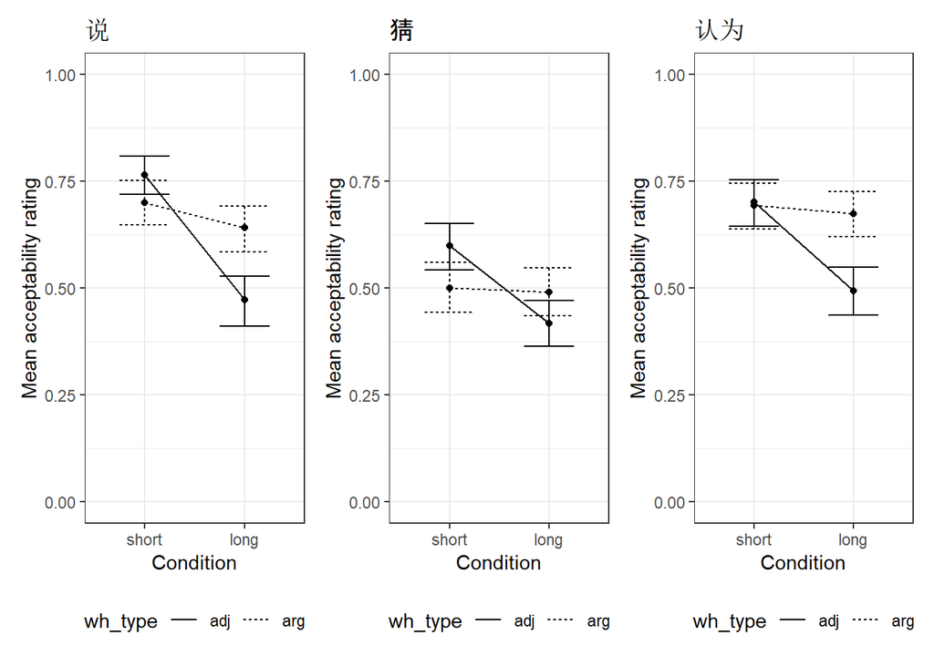

```r
plot_1 <-
  ggplot(data_1, aes(x = length, y = Mean, linetype  = wh_type, group = wh_type)) +
  geom_line() +
  geom_point() +
  geom_errorbar(aes(ymin = YMin, ymax = YMax), width = 0.5,  show.legend = FALSE) +
  scale_color_manual(values = cbPalette, name = NULL) +
  theme_bw() +
  xlab("Condition") +
  ylab("Mean acceptability rating") +
  theme(legend.position = "bottom") +
  ggtitle("说") +
  ylim(0,1)

data_9 <- data_no_fill %>%
  filter(verb_id %in% c(9)) %>%
  group_by( wh_type, length)%>%
  summarize(Mean = mean(response), CILow = ci.low(response), CIHigh = ci.high(response)) %>%
  ungroup() %>%
  mutate(YMin=Mean-CILow,YMax=Mean+CIHigh)
plot_9 <-
  ggplot(data_9, aes(x = length, y = Mean, linetype  = wh_type, group = wh_type)) +
  geom_line() +
  geom_point() +
  geom_errorbar(aes(ymin = YMin, ymax = YMax), width = 0.5,  show.legend = FALSE) +
  scale_color_manual(values = cbPalette, name = NULL) +
  theme_bw() +
  xlab("Condition") +
  ylab("Mean acceptability rating") +
  theme(legend.position = "bottom") +
  ggtitle("猜") +
  ylim(0,1)


data_13 <- data_no_fill %>%
  filter(verb_id %in% c(13)) %>%
  group_by( wh_type, length)%>%
  summarize(Mean = mean(response), CILow = ci.low(response), CIHigh = ci.high(response)) %>%
  ungroup() %>%
  mutate(YMin=Mean-CILow,YMax=Mean+CIHigh)
plot_13 <-
  ggplot(data_13, aes(x = length, y = Mean, linetype  = wh_type, group = wh_type)) +
  geom_line() +
  geom_point() +
  geom_errorbar(aes(ymin = YMin, ymax = YMax), width = 0.5,  show.legend = FALSE) +
  scale_color_manual(values = cbPalette, name = NULL) +
  theme_bw() +
  xlab("Condition") +
  ylab("Mean acceptability rating") +
  theme(legend.position = "bottom") +
  ggtitle("认为") +
  ylim(0,1)

combined_plot_bridge <- (plot_1 | plot_9 | plot_13)
combined_plot_bridge
```

Now, turning to the unclassified verbs:

```r
data_2 <- data_no_fill %>%
  filter(verb_id %in% c(1,9,13,2)) %>%
  group_by(verb_type, wh_type, length)%>%
  summarize(Mean = mean(response), CILow = ci.low(response), CIHigh = ci.high(response)) %>%
  ungroup() %>%
  mutate(YMin=Mean-CILow,YMax=Mean+CIHigh)
```

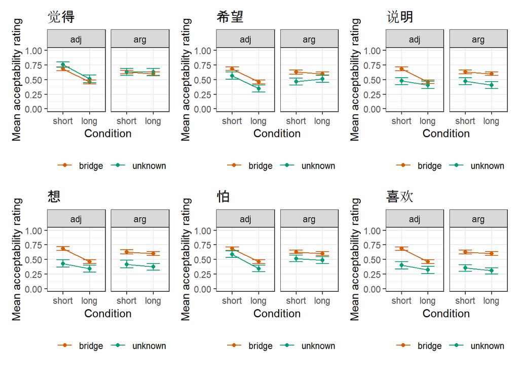

```r
plot_2 <-
  ggplot(data_2, aes(x = length, y = Mean, color = verb_type, group = verb_type)) +
  geom_line() +
  geom_point() +
  geom_errorbar(aes(ymin = YMin, ymax = YMax), width = 0.5,  show.legend = FALSE) +
  scale_color_manual(values = cbPalette, name = NULL) +
  theme_bw() +
  xlab("Condition") +
  ylab("Mean acceptability rating") +
  theme(legend.position = "bottom") +
  ggtitle("觉得") +
  ylim(0,1)+
  facet_wrap(~wh_type)



data_3 <- data_no_fill %>%
  filter(verb_id %in% c(1,9,13, 3)) %>%
  group_by(verb_type, wh_type, length)%>%
  summarize(Mean = mean(response), CILow = ci.low(response), CIHigh = ci.high(response)) %>%
  ungroup() %>%
  mutate(YMin=Mean-CILow,YMax=Mean+CIHigh)
plot_3 <-
  ggplot(data_3, aes(x = length, y = Mean, color = verb_type, group = verb_type)) +
  geom_line() +
  geom_point() +
  geom_errorbar(aes(ymin = YMin, ymax = YMax), width = 0.5,  show.legend = FALSE) +
  scale_color_manual(values = cbPalette, name = NULL) +
  theme_bw() +
  xlab("Condition") +
  ylab("Mean acceptability rating") +
  theme(legend.position = "bottom") +
  ggtitle("希望") +
  ylim(0,1)+
  facet_wrap(~wh_type)




data_4 <- data_no_fill %>%
  filter(verb_id %in% c(1,9,13, 4)) %>%
  group_by(verb_type, wh_type, length)%>%
  summarize(Mean = mean(response), CILow = ci.low(response), CIHigh = ci.high(response)) %>%
  ungroup() %>%
  mutate(YMin=Mean-CILow,YMax=Mean+CIHigh)
plot_4 <-
  ggplot(data_4, aes(x = length, y = Mean, color = verb_type, group = verb_type)) +
  geom_line() +
  geom_point() +
  geom_errorbar(aes(ymin = YMin, ymax = YMax), width = 0.5,  show.legend = FALSE) +
  scale_color_manual(values = cbPalette, name = NULL) +
  theme_bw() +
  xlab("Condition") +
  ylab("Mean acceptability rating") +
  theme(legend.position = "bottom") +
  ggtitle("说明") +
  ylim(0,1)+
  facet_wrap(~wh_type)



data_5 <- data_no_fill %>%
  filter(verb_id %in% c(1,9,13,5)) %>%
  group_by(verb_type, wh_type, length)%>%
  summarize(Mean = mean(response), CILow = ci.low(response), CIHigh = ci.high(response)) %>%
  ungroup() %>%
  mutate(YMin=Mean-CILow,YMax=Mean+CIHigh)
plot_5 <-
  ggplot(data_5, aes(x = length, y = Mean, color = verb_type, group = verb_type)) +
  geom_line() +
  geom_point() +
  geom_errorbar(aes(ymin = YMin, ymax = YMax), width = 0.5,  show.legend = FALSE) +
  scale_color_manual(values = cbPalette, name = NULL) +
  theme_bw() +
  xlab("Condition") +
  ylab("Mean acceptability rating") +
  theme(legend.position = "bottom") +
  ggtitle("想") +
  ylim(0,1)+
  facet_wrap(~wh_type)



data_6 <- data_no_fill %>%
  filter(verb_id %in% c(1,9,13,6)) %>%
  group_by(verb_type, wh_type, length)%>%
  summarize(Mean = mean(response), CILow = ci.low(response), CIHigh = ci.high(response)) %>%
  ungroup() %>%
  mutate(YMin=Mean-CILow,YMax=Mean+CIHigh)
plot_6 <-
  ggplot(data_6, aes(x = length, y = Mean, color = verb_type, group = verb_type)) +
  geom_line() +
  geom_point() +
  geom_errorbar(aes(ymin = YMin, ymax = YMax), width = 0.5,  show.legend = FALSE) +
  scale_color_manual(values = cbPalette, name = NULL) +
  theme_bw() +
  xlab("Condition") +
  ylab("Mean acceptability rating") +
  theme(legend.position = "bottom") +
  ggtitle("怕") +
  ylim(0,1)+
  facet_wrap(~wh_type)




data_7 <- data_no_fill %>%
  filter(verb_id %in% c(1,9,13, 7)) %>%
  group_by(verb_type, wh_type, length)%>%
  summarize(Mean = mean(response), CILow = ci.low(response), CIHigh = ci.high(response)) %>%
  ungroup() %>%
  mutate(YMin=Mean-CILow,YMax=Mean+CIHigh)
plot_7 <-
  ggplot(data_7, aes(x = length, y = Mean, color = verb_type, group = verb_type)) +
  geom_line() +
  geom_point() +
  geom_errorbar(aes(ymin = YMin, ymax = YMax), width = 0.5,  show.legend = FALSE) +
  scale_color_manual(values = cbPalette, name = NULL) +
  theme_bw() +
  xlab("Condition") +
  ylab("Mean acceptability rating") +
  theme(legend.position = "bottom") +
  ggtitle("喜欢") +
  ylim(0,1)+
  facet_wrap(~wh_type)



data_8 <- data_no_fill %>%
  filter(verb_id %in% c(1,9,13, 8)) %>%
  group_by(verb_type, wh_type, length)%>%
  summarize(Mean = mean(response), CILow = ci.low(response), CIHigh = ci.high(response)) %>%
  ungroup() %>%
  mutate(YMin=Mean-CILow,YMax=Mean+CIHigh)
plot_8 <-
  ggplot(data_8, aes(x = length, y = Mean, color = verb_type, group = verb_type)) +
  geom_line() +
  geom_point() +
  geom_errorbar(aes(ymin = YMin, ymax = YMax), width = 0.5,  show.legend = FALSE) +
  scale_color_manual(values = cbPalette, name = NULL) +
  theme_bw() +
  xlab("Condition") +
  ylab("Mean acceptability rating") +
  theme(legend.position = "bottom") +
  ggtitle("记得") +
  ylim(0,1)+
  facet_wrap(~wh_type)



data_10 <- data_no_fill %>%
  filter(verb_id %in% c(1,9,13, 10)) %>%
  group_by(verb_type, wh_type, length)%>%
  summarize(Mean = mean(response), CILow = ci.low(response), CIHigh = ci.high(response)) %>%
  ungroup() %>%
  mutate(YMin=Mean-CILow,YMax=Mean+CIHigh)
plot_10 <-
  ggplot(data_10, aes(x = length, y = Mean, color = verb_type, group = verb_type)) +
  geom_line() +
  geom_point() +
  geom_errorbar(aes(ymin = YMin, ymax = YMax), width = 0.5,  show.legend = FALSE) +
  scale_color_manual(values = cbPalette, name = NULL) +
  theme_bw() +
  xlab("Condition") +
  ylab("Mean acceptability rating") +
  theme(legend.position = "bottom") +
  ggtitle("假装") +
  ylim(0,1)+
  facet_wrap(~wh_type)



data_11 <- data_no_fill %>%
  filter(verb_id %in% c(1,9,13, 11)) %>%
  group_by(verb_type, wh_type, length)%>%
  summarize(Mean = mean(response), CILow = ci.low(response), CIHigh = ci.high(response)) %>%
  ungroup() %>%
  mutate(YMin=Mean-CILow,YMax=Mean+CIHigh)
plot_11 <-
  ggplot(data_11, aes(x = length, y = Mean, color = verb_type, group = verb_type)) +
  geom_line() +
  geom_point() +
  geom_errorbar(aes(ymin = YMin, ymax = YMax), width = 0.5,  show.legend = FALSE) +
  scale_color_manual(values = cbPalette, name = NULL) +
  theme_bw() +
  xlab("Condition") +
  ylab("Mean acceptability rating") +
  theme(legend.position = "bottom") +
  ggtitle("害怕") +
  ylim(0,1)+
  facet_wrap(~wh_type)




data_12 <- data_no_fill %>%
  filter(verb_id %in% c(1,9,13, 12)) %>%
  group_by(verb_type, wh_type, length)%>%
  summarize(Mean = mean(response), CILow = ci.low(response), CIHigh = ci.high(response)) %>%
  ungroup() %>%
  mutate(YMin=Mean-CILow,YMax=Mean+CIHigh)
plot_12 <-
  ggplot(data_12, aes(x = length, y = Mean, color = verb_type, group = verb_type)) +
  geom_line() +
  geom_point() +
  geom_errorbar(aes(ymin = YMin, ymax = YMax), width = 0.5,  show.legend = FALSE) +
  scale_color_manual(values = cbPalette, name = NULL) +
  theme_bw() +
  xlab("Condition") +
  ylab("Mean acceptability rating") +
  theme(legend.position = "bottom") +
  ggtitle("感觉") +
  ylim(0,1)+
  facet_wrap(~wh_type)


data_14 <- data_no_fill %>%
  filter(verb_id %in% c(1,9,13, 14)) %>%
  group_by(verb_type, wh_type, length)%>%
  summarize(Mean = mean(response), CILow = ci.low(response), CIHigh = ci.high(response)) %>%
  ungroup() %>%
  mutate(YMin=Mean-CILow,YMax=Mean+CIHigh)
plot_14 <-
  ggplot(data_14, aes(x = length, y = Mean, color = verb_type, group = verb_type)) +
  geom_line() +
  geom_point() +
  geom_errorbar(aes(ymin = YMin, ymax = YMax), width = 0.5,  show.legend = FALSE) +
  scale_color_manual(values = cbPalette, name = NULL) +
  theme_bw() +
  xlab("Condition") +
  ylab("Mean acceptability rating") +
  theme(legend.position = "bottom") +
  ggtitle("写") +
  ylim(0,1)+
  facet_wrap(~wh_type)


combined_plot1 <- (plot_2 | plot_3 | plot_4) /
  (plot_5 | plot_6 | plot_7)
combined_plot1
```

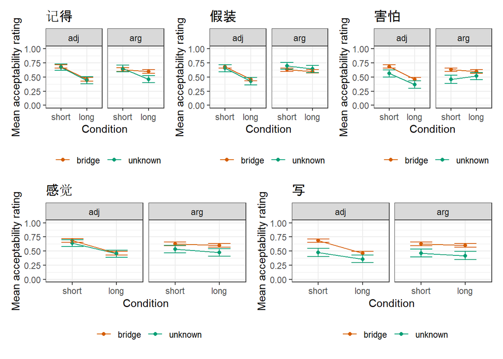

```r
combined_plot2 <- (plot_8 | plot_10 | plot_11) /
  (plot_12 | plot_14 )
combined_plot2
```

First, getting the data ready for stats:

```r
data_no_fill$length <- as.factor(data_no_fill$length)
data_no_fill$verb_type <- as.factor(data_no_fill$verb_type)
data_no_fill$wh_type <- as.factor(data_no_fill$wh_type)
data_no_fill$length <- relevel(data_no_fill$length, ref = "short")
data_no_fill$verb_type <- relevel(data_no_fill$verb_type, ref = "bridge")
data_no_fill$wh_type <- relevel(data_no_fill$wh_type, ref = "adj")
contrasts(data_no_fill$length) <- contr.sum(2)
contrasts(data_no_fill$verb_type) <- contr.sum(2)
contrasts(data_no_fill$wh_type) <- contr.sum(2)
```

```r
model_bridge <- lmer(response ~ length * wh_type +
                  (1+ length * wh_type |workerid) +
                  (1 + length * wh_type | item),
                data = subset(data_no_fill, verb_id %in% c(1,9,13)))
```

```
## boundary (singular) fit: see help('isSingular')
```

```r
summary(model_bridge)
```

```
## Linear mixed model fit by REML. t-tests use Satterthwaite's method [
## lmerModLmerTest]
## Formula: response ~ length * wh_type + (1 + length * wh_type | workerid) +
##     (1 + length * wh_type | item)
##    Data: subset(data_no_fill, verb_id %in% c(1, 9, 13))
##
## REML criterion at convergence: 909.7
##
## Scaled residuals:
##     Min      1Q  Median      3Q     Max
## -2.7955 -0.6537  0.1531  0.6533  2.2890
##
## Random effects:
##  Groups   Name             Variance  Std.Dev. Corr
##  workerid (Intercept)      2.340e-02 0.152967
##           length1          6.868e-03 0.082870 -0.06
##           wh_type1         1.309e-03 0.036179 -0.31 -0.78
##           length1:wh_type1 2.006e-03 0.044788 -0.11  0.98 -0.86
##  item     (Intercept)      3.604e-03 0.060033
##           length1          2.485e-04 0.015763  0.18
##           wh_type1         5.003e-05 0.007073  0.52 -0.75
##           length1:wh_type1 4.492e-05 0.006702 -0.13  0.95 -0.92
##  Residual                  7.556e-02 0.274883
## Number of obs: 1672, groups:  workerid, 209; item, 32
##
## Fixed effects:
##                    Estimate Std. Error         df t value Pr(>|t|)
## (Intercept)        0.591581   0.016447  72.335952  35.969  < 2e-16 ***
## length1            0.062922   0.009290  56.959437   6.773 7.61e-09 ***
## wh_type1          -0.021105   0.007326 128.326820  -2.881  0.00465 **
## length1:wh_type1   0.049789   0.007546  99.474237   6.598 2.04e-09 ***
## ---
## Signif. codes:  0 '***' 0.001 '**' 0.01 '*' 0.05 '.' 0.1 ' ' 1
##
## Correlation of Fixed Effects:
##             (Intr) lngth1 wh_ty1
## length1      0.010
## wh_type1    -0.010 -0.206
## lngth1:wh_1 -0.042  0.293 -0.146
## optimizer (nloptwrap) convergence code: 0 (OK)
## boundary (singular) fit: see help('isSingular')
```

Then, for each unclassified verb, we can examine: (a) if the argument-adjunct asymmetry in the length penalty exists, as in the three bridge verbs; (b) if the length penalty is greater than the one seen for bridge verbs (i.e., showing a “bridge effect).

1. verb = 觉得: there is arg-adj asymmetry in the length penalty, and no bridge effect in either wh-argument or wh-adjunct condition.

```r
model_2 <- lmer(response ~ wh_type * length  +
                  (1+wh_type * length - length |item) +
                  (1+ wh_type + length|workerid),
                data = subset(data_no_fill, verb_id %in% c(2)))
```

```
## boundary (singular) fit: see help('isSingular')
```

```r
summary(model_2)
```

```
## Linear mixed model fit by REML. t-tests use Satterthwaite's method [
## lmerModLmerTest]
## Formula: response ~ wh_type * length + (1 + wh_type * length - length |
##     item) + (1 + wh_type + length | workerid)
##    Data: subset(data_no_fill, verb_id %in% c(2))
##
## REML criterion at convergence: 240
##
## Scaled residuals:
##     Min      1Q  Median      3Q     Max
## -2.2511 -0.6308  0.1885  0.6156  1.6181
##
## Random effects:
##  Groups   Name               Variance Std.Dev. Corr
##  workerid (Intercept)        0.018873 0.13738
##           wh_type1           0.007243 0.08511  -0.03
##           length1            0.005099 0.07141  -0.66 -0.73
##  item     (Intercept)        0.004815 0.06939
##           wh_type1           0.002381 0.04880  -0.11
##           wh_typeadj:length1 0.002531 0.05030  -0.51  0.91
##           wh_typearg:length1 0.004460 0.06679  -0.20 -0.95 -0.74
##  Residual                    0.061665 0.24832
## Number of obs: 452, groups:  workerid, 113; item, 32
##
## Fixed effects:
##                  Estimate Std. Error       df t value Pr(>|t|)
## (Intercept)       0.63568    0.02155 48.82316  29.503  < 2e-16 ***
## wh_type1          0.00273    0.01695 44.46367   0.161 0.872785
## length1           0.05955    0.01446 79.04034   4.119 9.29e-05 ***
## wh_type1:length1  0.06185    0.01563 26.42809   3.957 0.000512 ***
## ---
## Signif. codes:  0 '***' 0.001 '**' 0.01 '*' 0.05 '.' 0.1 ' ' 1
##
## Correlation of Fixed Effects:
##             (Intr) wh_ty1 lngth1
## wh_type1    -0.038
## length1     -0.305 -0.219
## wh_typ1:ln1 -0.048  0.304 -0.068
## optimizer (nloptwrap) convergence code: 0 (OK)
## boundary (singular) fit: see help('isSingular')
```

```r
model_2arg <- lmer(response ~ verb_type * length+
                   (1 + verb_type * length|item) +
                   (1 + verb_type * length - verb_type|workerid),
                 data = subset(subset(data_no_fill, verb_id %in% c(1,9,13,2)), wh_type == "arg")
)
```

```
## boundary (singular) fit: see help('isSingular')
```

```r
summary(model_2arg)
```

```
## Linear mixed model fit by REML. t-tests use Satterthwaite's method [
## lmerModLmerTest]
## Formula: response ~ verb_type * length + (1 + verb_type * length | item) +
##     (1 + verb_type * length - verb_type | workerid)
##    Data: subset(subset(data_no_fill, verb_id %in% c(1, 9, 13, 2)), wh_type ==
##     "arg")
##
## REML criterion at convergence: 631.5
##
## Scaled residuals:
##     Min      1Q  Median      3Q     Max
## -2.5231 -0.6895  0.2427  0.6850  2.1296
##
## Random effects:
##  Groups   Name                   Variance  Std.Dev. Corr
##  workerid (Intercept)            2.523e-02 0.158833
##           length1                4.838e-05 0.006956 -0.79
##           verb_type1:lengthshort 2.085e-04 0.014438  0.96 -0.93
##           verb_type1:lengthlong  1.349e-04 0.011614 -0.99  0.87 -0.99
##  item     (Intercept)            3.806e-03 0.061691
##           verb_type1             9.038e-04 0.030063 -0.43
##           length1                1.194e-03 0.034554  0.94 -0.11
##           verb_type1:length1     7.203e-04 0.026838 -0.36 -0.69 -0.65
##  Residual                        8.339e-02 0.288774
## Number of obs: 1062, groups:  workerid, 209; item, 32
##
## Fixed effects:
##                     Estimate Std. Error        df t value Pr(>|t|)
## (Intercept)         0.619660   0.019300 57.054212  32.106   <2e-16 ***
## verb_type1         -0.006936   0.012678 40.272653  -0.547    0.587
## length1             0.003354   0.012662 37.425403   0.265    0.793
## verb_type1:length1  0.009904   0.012087 47.138815   0.819    0.417
## ---
## Signif. codes:  0 '***' 0.001 '**' 0.01 '*' 0.05 '.' 0.1 ' ' 1
##
## Correlation of Fixed Effects:
##             (Intr) vrb_t1 lngth1
## verb_type1  -0.433
## length1      0.239 -0.017
## vrb_typ1:l1 -0.035 -0.117 -0.596
## optimizer (nloptwrap) convergence code: 0 (OK)
## boundary (singular) fit: see help('isSingular')
```

```r
model_2adj <- lmer(response ~ verb_type * length+
                   (1 + verb_type * length |item) +
                   (1 + verb_type * length|workerid),

                 data = subset(subset(data_no_fill, verb_id %in% c(1,9,13,2)), wh_type == "adj")
)
```

```
## boundary (singular) fit: see help('isSingular')
```

```r
summary(model_2adj)
```

```
## Linear mixed model fit by REML. t-tests use Satterthwaite's method [
## lmerModLmerTest]
## Formula: response ~ verb_type * length + (1 + verb_type * length | item) +
##     (1 + verb_type * length | workerid)
##    Data: subset(subset(data_no_fill, verb_id %in% c(1, 9, 13, 2)), wh_type ==
##     "adj")
##
## REML criterion at convergence: 522.2
##
## Scaled residuals:
##     Min      1Q  Median      3Q     Max
## -2.9709 -0.5485  0.1422  0.5918  2.4329
##
## Random effects:
##  Groups   Name               Variance  Std.Dev. Corr
##  workerid (Intercept)        2.671e-02 0.16342
##           verb_type1         1.006e-03 0.03172  -0.25
##           length1            1.244e-02 0.11155  -0.46 -0.08
##           verb_type1:length1 2.180e-03 0.04669   0.51 -0.52  0.50
##  item     (Intercept)        3.362e-03 0.05798
##           verb_type1         1.035e-03 0.03216  -0.20
##           length1            6.601e-04 0.02569   0.55 -0.10
##           verb_type1:length1 9.604e-05 0.00980  -0.63 -0.55 -0.07
##  Residual                    5.986e-02 0.24467
## Number of obs: 1062, groups:  workerid, 209; item, 32
##
## Fixed effects:
##                      Estimate Std. Error         df t value Pr(>|t|)
## (Intercept)          0.603003   0.018329  63.051978  32.900  < 2e-16 ***
## verb_type1          -0.032537   0.011846  25.038407  -2.747    0.011 *
## length1              0.116913   0.013140  63.199369   8.898 9.48e-13 ***
## verb_type1:length1  -0.004357   0.010300 174.428553  -0.423    0.673
## ---
## Signif. codes:  0 '***' 0.001 '**' 0.01 '*' 0.05 '.' 0.1 ' ' 1
##
## Correlation of Fixed Effects:
##             (Intr) vrb_t1 lngth1
## verb_type1  -0.386
## length1     -0.082  0.008
## vrb_typ1:l1  0.064 -0.117 -0.325
## optimizer (nloptwrap) convergence code: 0 (OK)
## boundary (singular) fit: see help('isSingular')
```

To verify the null results, we can run a bayes factor analysis: For the wh-arg condition, BF = 0.1220, and for the wh-adj condition, BF = 0.1107, both favoring the null hypothesis.

```r
BF_2_arg <- generalTestBF(response~verb_type + length + verb_type : length, data = subset(subset(data_no_fill, verb_id %in% c(1,9,13,2)), wh_type == "arg"), rscaleFixed = "medium")

BF_2_arg
```

```
## Bayes factor analysis
## --------------
## [1] verb_type                             : 0.1044572   ±0.18%
## [2] length                                : 0.1210751   ±0.17%
## [3] verb_type + length                    : 0.01215772  ±1.57%
## [4] verb_type + length + verb_type:length : 0.001615214 ±1.67%
##
## Against denominator:
##   Intercept only
## ---
## Bayes factor type: BFlinearModel, JZS
```

```r
BF_2_adj <- generalTestBF(response~verb_type + length + verb_type : length, data = subset(subset(data_no_fill, verb_id %in% c(1,9,13,2)), wh_type == "adj"), rscaleFixed = "medium")

BF_2_adj
```

```
## Bayes factor analysis
## --------------
## [1] verb_type                             : 1.26418      ±0.02%
## [2] length                                : 8.77255e+24  ±0%
## [3] verb_type + length                    : 1.532023e+25 ±0.87%
## [4] verb_type + length + verb_type:length : 1.800883e+24 ±3.43%
##
## Against denominator:
##   Intercept only
## ---
## Bayes factor type: BFlinearModel, JZS
```

2. verb = 希望: arg-adj asymmetry exists, marginal evidence for anti-bridge effect for wh-arg, and not for wh-adj.

```r
model_3 <- lmer(response ~ wh_type * length  +
                  (1+wh_type * length  |item) +
                  (1+ wh_type + length|workerid),
                data = subset(data_no_fill, verb_id %in% c(3)))
```

```
## boundary (singular) fit: see help('isSingular')
```

```r
summary(model_3)
```

```
## Linear mixed model fit by REML. t-tests use Satterthwaite's method [
## lmerModLmerTest]
## Formula: response ~ wh_type * length + (1 + wh_type * length | item) +
##     (1 + wh_type + length | workerid)
##    Data: subset(data_no_fill, verb_id %in% c(3))
##
## REML criterion at convergence: 313.6
##
## Scaled residuals:
##      Min       1Q   Median       3Q      Max
## -2.42411 -0.61664 -0.03778  0.68473  2.46150
##
## Random effects:
##  Groups   Name             Variance  Std.Dev. Corr
##  workerid (Intercept)      0.0350995 0.18735
##           wh_type1         0.0020091 0.04482   0.01
##           length1          0.0016483 0.04060  -0.13 -0.99
##  item     (Intercept)      0.0014265 0.03777
##           wh_type1         0.0012473 0.03532  -0.87
##           length1          0.0002936 0.01713   0.81 -0.99
##           wh_type1:length1 0.0011296 0.03361   0.53 -0.05 -0.07
##  Residual                  0.0765683 0.27671
## Number of obs: 480, groups:  workerid, 120; item, 32
##
## Fixed effects:
##                  Estimate Std. Error       df t value Pr(>|t|)
## (Intercept)       0.47488    0.02244 84.96769  21.159  < 2e-16 ***
## wh_type1         -0.01584    0.01491 32.95327  -1.062   0.2959
## length1           0.04094    0.01378 68.72626   2.970   0.0041 **
## wh_type1:length1  0.06700    0.01418 25.87142   4.724 7.04e-05 ***
## ---
## Signif. codes:  0 '***' 0.001 '**' 0.01 '*' 0.05 '.' 0.1 ' ' 1
##
## Correlation of Fixed Effects:
##             (Intr) wh_ty1 lngth1
## wh_type1    -0.121
## length1      0.030 -0.160
## wh_typ1:ln1  0.065  0.000 -0.025
## optimizer (nloptwrap) convergence code: 0 (OK)
## boundary (singular) fit: see help('isSingular')
```

```r
model_3arg <- lmer(response ~ verb_type * length+
                   (1 + verb_type * length|item) +
                   (1 + verb_type * length|workerid),
                 data = subset(subset(data_no_fill, verb_id %in% c(1,9,13,3)), wh_type == "arg")
)
```

```
## boundary (singular) fit: see help('isSingular')
```

```r
summary(model_3arg)
```

```
## Linear mixed model fit by REML. t-tests use Satterthwaite's method [
## lmerModLmerTest]
## Formula: response ~ verb_type * length + (1 + verb_type * length | item) +
##     (1 + verb_type * length | workerid)
##    Data: subset(subset(data_no_fill, verb_id %in% c(1, 9, 13, 3)), wh_type ==
##     "arg")
##
## REML criterion at convergence: 667.7
##
## Scaled residuals:
##     Min      1Q  Median      3Q     Max
## -2.5358 -0.7108  0.1720  0.7107  1.8536
##
## Random effects:
##  Groups   Name               Variance  Std.Dev. Corr
##  workerid (Intercept)        0.0264170 0.16253
##           verb_type1         0.0025293 0.05029  -0.25
##           length1            0.0001290 0.01136  -0.98  0.43
##           verb_type1:length1 0.0002250 0.01500   0.56  0.66 -0.40
##  item     (Intercept)        0.0023719 0.04870
##           verb_type1         0.0030964 0.05565  -0.34
##           length1            0.0006759 0.02600   0.78  0.14
##           verb_type1:length1 0.0006012 0.02452   0.15 -0.48 -0.47
##  Residual                    0.0840215 0.28986
## Number of obs: 1076, groups:  workerid, 209; item, 32
##
## Fixed effects:
##                     Estimate Std. Error        df t value Pr(>|t|)
## (Intercept)         0.549030   0.018419 63.854977  29.807  < 2e-16 ***
## verb_type1          0.064067   0.015753 30.063947   4.067 0.000317 ***
## length1            -0.008024   0.011892 40.547128  -0.675 0.503660
## verb_type1:length1  0.020688   0.011832 21.298055   1.748 0.094784 .
## ---
## Signif. codes:  0 '***' 0.001 '**' 0.01 '*' 0.05 '.' 0.1 ' ' 1
##
## Correlation of Fixed Effects:
##             (Intr) vrb_t1 lngth1
## verb_type1  -0.437
## length1      0.096  0.050
## vrb_typ1:l1  0.063 -0.102 -0.556
## optimizer (nloptwrap) convergence code: 0 (OK)
## boundary (singular) fit: see help('isSingular')
```

```r
model_3adj <- lmer(response ~ verb_type * length+
                   (1 + verb_type  |item) +
                   (1 + verb_type + length|workerid),

                 data = subset(subset(data_no_fill, verb_id %in% c(1,9,13,3)), wh_type == "adj")
)
```

```
## boundary (singular) fit: see help('isSingular')
```

```r
summary(model_3adj)
```

```
## Linear mixed model fit by REML. t-tests use Satterthwaite's method [
## lmerModLmerTest]
## Formula: response ~ verb_type * length + (1 + verb_type | item) + (1 +
##     verb_type + length | workerid)
##    Data: subset(subset(data_no_fill, verb_id %in% c(1, 9, 13, 3)), wh_type ==
##     "adj")
##
## REML criterion at convergence: 606.2
##
## Scaled residuals:
##      Min       1Q   Median       3Q      Max
## -2.65220 -0.57299  0.08846  0.63001  2.30900
##
## Random effects:
##  Groups   Name        Variance  Std.Dev. Corr
##  workerid (Intercept) 0.0275669 0.16603
##           verb_type1  0.0057363 0.07574  -0.39
##           length1     0.0156285 0.12501  -0.37  0.22
##  item     (Intercept) 0.0007485 0.02736
##           verb_type1  0.0009777 0.03127  1.00
##  Residual             0.0667943 0.25845
## Number of obs: 1076, groups:  workerid, 209; item, 32
##
## Fixed effects:
##                     Estimate Std. Error        df t value Pr(>|t|)
## (Intercept)        5.194e-01  1.649e-02 1.119e+02  31.507  < 2e-16 ***
## verb_type1         5.121e-02  1.321e-02 5.476e+01   3.877 0.000286 ***
## length1            1.117e-01  1.310e-02 2.871e+02   8.525 8.85e-16 ***
## verb_type1:length1 6.788e-04  9.841e-03 5.968e+02   0.069 0.945034
## ---
## Signif. codes:  0 '***' 0.001 '**' 0.01 '*' 0.05 '.' 0.1 ' ' 1
##
## Correlation of Fixed Effects:
##             (Intr) vrb_t1 lngth1
## verb_type1  -0.332
## length1     -0.185  0.077
## vrb_typ1:l1  0.019 -0.025 -0.437
## optimizer (nloptwrap) convergence code: 0 (OK)
## boundary (singular) fit: see help('isSingular')
```

To verify the null results, we can run a bayes factor analysis: For the wh-arg condition, BF = 0.3520 (inconclusive); for the wh-adj condition, BF = 0.1223, favoring the null hypothesis.

```r
BF_3_arg <- generalTestBF(response~verb_type + length + verb_type : length, data = subset(subset(data_no_fill, verb_id %in% c(1,9,13,3)), wh_type == "arg"), rscaleFixed = "medium")

BF_3_arg
```

```
## Bayes factor analysis
## --------------
## [1] verb_type                             : 14080.74   ±0%
## [2] length                                : 0.07986446 ±0.26%
## [3] verb_type + length                    : 1135.417   ±1.02%
## [4] verb_type + length + verb_type:length : 368.4914   ±2.68%
##
## Against denominator:
##   Intercept only
## ---
## Bayes factor type: BFlinearModel, JZS
```

```r
BF_3_adj <- generalTestBF(response~verb_type + length + verb_type : length, data = subset(subset(data_no_fill, verb_id %in% c(1,9,13,3)), wh_type == "adj"), rscaleFixed = "medium")

BF_3_adj
```

```
## Bayes factor analysis
## --------------
## [1] verb_type                             : 1347.377     ±0%
## [2] length                                : 4.953076e+22 ±0%
## [3] verb_type + length                    : 1.908486e+26 ±2.19%
## [4] verb_type + length + verb_type:length : 2.283637e+25 ±3.85%
##
## Against denominator:
##   Intercept only
## ---
## Bayes factor type: BFlinearModel, JZS
```

3. verb = 说明: no arg-adjunct asymmetry; for wh-adjunct, there is an “anti-bridge effect”; for wh-argument, there is no evidence for bridge effect.

```r
model_4 <- lmer(response ~ wh_type * length  +
                  (1+wh_type * length  |item) +
                  (1+ wh_type + length|workerid),
                data = subset(data_no_fill, verb_id %in% c(4)))
```

```
## boundary (singular) fit: see help('isSingular')
```

```r
summary(model_4)
```

```
## Linear mixed model fit by REML. t-tests use Satterthwaite's method [
## lmerModLmerTest]
## Formula: response ~ wh_type * length + (1 + wh_type * length | item) +
##     (1 + wh_type + length | workerid)
##    Data: subset(data_no_fill, verb_id %in% c(4))
##
## REML criterion at convergence: 275.9
##
## Scaled residuals:
##      Min       1Q   Median       3Q      Max
## -2.59005 -0.49125 -0.08813  0.58483  2.73572
##
## Random effects:
##  Groups   Name             Variance  Std.Dev.  Corr
##  workerid (Intercept)      5.733e-02 0.2394281
##           wh_type1         5.832e-05 0.0076368 0.30
##           length1          2.921e-03 0.0540490 0.06 0.97
##  item     (Intercept)      6.264e-04 0.0250285
##           wh_type1         2.788e-05 0.0052797 1.00
##           length1          4.530e-04 0.0212842 1.00 1.00
##           wh_type1:length1 4.079e-07 0.0006387 1.00 1.00 1.00
##  Residual                  6.154e-02 0.2480678
## Number of obs: 512, groups:  workerid, 128; item, 32
##
## Fixed effects:
##                    Estimate Std. Error         df t value Pr(>|t|)
## (Intercept)       4.388e-01  2.428e-02  1.121e+02  18.077   <2e-16 ***
## wh_type1          7.743e-04  1.108e-02  1.789e+02   0.070   0.9444
## length1           3.238e-02  1.261e-02  4.454e+01   2.569   0.0136 *
## wh_type1:length1 -4.420e-04  1.103e-02  2.499e+02  -0.040   0.9681
## ---
## Signif. codes:  0 '***' 0.001 '**' 0.01 '*' 0.05 '.' 0.1 ' ' 1
##
## Correlation of Fixed Effects:
##             (Intr) wh_ty1 lngth1
## wh_type1    0.033
## length1     0.080  0.051
## wh_typ1:ln1 0.004  0.012  0.007
## optimizer (nloptwrap) convergence code: 0 (OK)
## boundary (singular) fit: see help('isSingular')
```

```r
model_4arg <- lmer(response ~ verb_type * length+
                   (0+ verb_type |item) +
                   (1 + verb_type |workerid),
                 data = subset(subset(data_no_fill, verb_id %in% c(1,9,13,4)), wh_type == "arg")
)
```

```
## boundary (singular) fit: see help('isSingular')
```

```r
summary(model_4arg)
```

```
## Linear mixed model fit by REML. t-tests use Satterthwaite's method [
## lmerModLmerTest]
## Formula: response ~ verb_type * length + (0 + verb_type | item) + (1 +
##     verb_type | workerid)
##    Data: subset(subset(data_no_fill, verb_id %in% c(1, 9, 13, 4)), wh_type ==
##     "arg")
##
## REML criterion at convergence: 675.4
##
## Scaled residuals:
##     Min      1Q  Median      3Q     Max
## -2.5099 -0.6775  0.1530  0.7001  2.1330
##
## Random effects:
##  Groups   Name             Variance  Std.Dev. Corr
##  workerid (Intercept)      0.0304654 0.17454
##           verb_type1       0.0034809 0.05900  -0.44
##  item     verb_typebridge  0.0034742 0.05894
##           verb_typeunknown 0.0001639 0.01280  -1.00
##  Residual                  0.0847907 0.29119
## Number of obs: 1092, groups:  workerid, 209; item, 32
##
## Fixed effects:
##                     Estimate Std. Error        df t value Pr(>|t|)
## (Intercept)          0.53379    0.01708 128.50728  31.253  < 2e-16 ***
## verb_type1           0.07936    0.01365  44.39424   5.815 6.12e-07 ***
## length1              0.02348    0.01043 733.04101   2.252   0.0246 *
## verb_type1:length1  -0.01004    0.01042 736.77206  -0.964   0.3353
## ---
## Signif. codes:  0 '***' 0.001 '**' 0.01 '*' 0.05 '.' 0.1 ' ' 1
##
## Correlation of Fixed Effects:
##             (Intr) vrb_t1 lngth1
## verb_type1  -0.316
## length1      0.001  0.000
## vrb_typ1:l1  0.000  0.000 -0.525
## optimizer (nloptwrap) convergence code: 0 (OK)
## boundary (singular) fit: see help('isSingular')
```

```r
model_4adj <- lmer(response ~ verb_type * length+
                   (1 + verb_type + length|item) +
                   (1 + verb_type * length|workerid),

                 data = subset(subset(data_no_fill, verb_id %in% c(1,9,13,4)), wh_type == "adj")
)
```

```
## boundary (singular) fit: see help('isSingular')
```

```r
summary(model_4adj)
```

```
## Linear mixed model fit by REML. t-tests use Satterthwaite's method [
## lmerModLmerTest]
## Formula: response ~ verb_type * length + (1 + verb_type + length | item) +
##     (1 + verb_type * length | workerid)
##    Data: subset(subset(data_no_fill, verb_id %in% c(1, 9, 13, 4)), wh_type ==
##     "adj")
##
## REML criterion at convergence: 566.4
##
## Scaled residuals:
##      Min       1Q   Median       3Q      Max
## -2.61393 -0.52912  0.06966  0.59868  2.85973
##
## Random effects:
##  Groups   Name               Variance  Std.Dev. Corr
##  workerid (Intercept)        0.0366855 0.19153
##           verb_type1         0.0049284 0.07020  -0.64
##           length1            0.0071293 0.08444  -0.41  0.79
##           verb_type1:length1 0.0032294 0.05683  -0.69  0.96  0.90
##  item     (Intercept)        0.0014824 0.03850
##           verb_type1         0.0007049 0.02655   0.55
##           length1            0.0008483 0.02913   0.31 -0.62
##  Residual                    0.0626319 0.25026
## Number of obs: 1092, groups:  workerid, 209; item, 32
##
## Fixed effects:
##                     Estimate Std. Error        df t value Pr(>|t|)
## (Intercept)        5.081e-01  1.793e-02 1.081e+02  28.329  < 2e-16 ***
## verb_type1         6.259e-02  1.207e-02 6.440e+01   5.186 2.33e-06 ***
## length1            7.307e-02  1.196e-02 5.945e+01   6.110 8.29e-08 ***
## verb_type1:length1 4.002e-02  9.886e-03 3.308e+02   4.048 6.43e-05 ***
## ---
## Signif. codes:  0 '***' 0.001 '**' 0.01 '*' 0.05 '.' 0.1 ' ' 1
##
## Correlation of Fixed Effects:
##             (Intr) vrb_t1 lngth1
## verb_type1  -0.392
## length1     -0.091  0.037
## vrb_typ1:l1 -0.213  0.168 -0.197
## optimizer (nloptwrap) convergence code: 0 (OK)
## boundary (singular) fit: see help('isSingular')
```

To verify the null result for wh-arg, we can run a bayes factor analysis: BF = 0.1536, favoring the null hypothesis.

```r
BF_4_arg <- generalTestBF(response~verb_type + length + verb_type : length, data = subset(subset(data_no_fill, verb_id %in% c(1,9,13,4)), wh_type == "arg"), rscaleFixed = "medium")

BF_4_arg
```

```
## Bayes factor analysis
## --------------
## [1] verb_type                             : 4851585312 ±0%
## [2] length                                : 0.3198383  ±0.07%
## [3] verb_type + length                    : 1682832172 ±0.94%
## [4] verb_type + length + verb_type:length : 243645963  ±1.38%
##
## Against denominator:
##   Intercept only
## ---
## Bayes factor type: BFlinearModel, JZS
```

4. verb = 想: no argument-adjunct asymmetry; anti-bridge effect for wh-adjunct, and no bridge effect for wh-argument.

```r
model_5 <- lmer(response ~ wh_type * length  +
                  (1+wh_type * length  |item) +
                  (1 + length|workerid),
                data = subset(data_no_fill, verb_id %in% c(5)))
```

```
## boundary (singular) fit: see help('isSingular')
```

```r
summary(model_5)
```

```
## Linear mixed model fit by REML. t-tests use Satterthwaite's method [
## lmerModLmerTest]
## Formula: response ~ wh_type * length + (1 + wh_type * length | item) +
##     (1 + length | workerid)
##    Data: subset(data_no_fill, verb_id %in% c(5))
##
## REML criterion at convergence: 264.3
##
## Scaled residuals:
##     Min      1Q  Median      3Q     Max
## -2.5246 -0.5273 -0.1466  0.5203  2.7163
##
## Random effects:
##  Groups   Name             Variance  Std.Dev. Corr
##  workerid (Intercept)      0.0560795 0.23681
##           length1          0.0017935 0.04235  0.71
##  item     (Intercept)      0.0006852 0.02618
##           wh_type1         0.0008022 0.02832  -0.55
##           length1          0.0018148 0.04260   0.20  0.71
##           wh_type1:length1 0.0005501 0.02345  -0.79 -0.08 -0.76
##  Residual                  0.0619356 0.24887
## Number of obs: 488, groups:  workerid, 122; item, 32
##
## Fixed effects:
##                    Estimate Std. Error         df t value Pr(>|t|)
## (Intercept)        0.392492   0.024749 102.885945  15.859   <2e-16 ***
## wh_type1          -0.005723   0.012515  30.930868  -0.457   0.6506
## length1            0.032567   0.014251  22.013697   2.285   0.0323 *
## wh_type1:length1   0.011118   0.012190  52.209281   0.912   0.3659
## ---
## Signif. codes:  0 '***' 0.001 '**' 0.01 '*' 0.05 '.' 0.1 ' ' 1
##
## Correlation of Fixed Effects:
##             (Intr) wh_ty1 lngth1
## wh_type1    -0.050
## length1      0.184  0.158
## wh_typ1:ln1 -0.047 -0.013 -0.153
## optimizer (nloptwrap) convergence code: 0 (OK)
## boundary (singular) fit: see help('isSingular')
```

```r
model_5arg <- lmer(response ~ verb_type * length+
                   (1 +verb_type * length|item) +
                   (1 + verb_type * length|workerid),
                 data = subset(subset(data_no_fill, verb_id %in% c(1,9,13,5)), wh_type == "arg")
)
```

```
## boundary (singular) fit: see help('isSingular')
```

```r
summary(model_5arg)
```

```
## Linear mixed model fit by REML. t-tests use Satterthwaite's method [
## lmerModLmerTest]
## Formula: response ~ verb_type * length + (1 + verb_type * length | item) +
##     (1 + verb_type * length | workerid)
##    Data: subset(subset(data_no_fill, verb_id %in% c(1, 9, 13, 5)), wh_type ==
##     "arg")
##
## REML criterion at convergence: 667.8
##
## Scaled residuals:
##     Min      1Q  Median      3Q     Max
## -2.4966 -0.6931  0.1581  0.7034  2.2250
##
## Random effects:
##  Groups   Name               Variance  Std.Dev. Corr
##  workerid (Intercept)        2.913e-02 0.17067
##           verb_type1         4.075e-03 0.06384  -0.38
##           length1            1.983e-04 0.01408   1.00 -0.41
##           verb_type1:length1 1.119e-04 0.01058  -0.89 -0.08 -0.88
##  item     (Intercept)        1.520e-03 0.03898
##           verb_type1         8.721e-04 0.02953   0.32
##           length1            7.885e-05 0.00888  -0.98 -0.48
##           verb_type1:length1 7.815e-04 0.02795   0.20  0.99 -0.36
##  Residual                    8.388e-02 0.28962
## Number of obs: 1080, groups:  workerid, 209; item, 32
##
## Fixed effects:
##                      Estimate Std. Error         df t value Pr(>|t|)
## (Intercept)          0.504195   0.017990  84.057883  28.026  < 2e-16 ***
## verb_type1           0.108790   0.013544  45.155466   8.032 3.02e-10 ***
## length1              0.016151   0.010793 184.595788   1.496    0.136
## verb_type1:length1  -0.002257   0.011761  33.701948  -0.192    0.849
## ---
## Signif. codes:  0 '***' 0.001 '**' 0.01 '*' 0.05 '.' 0.1 ' ' 1
##
## Correlation of Fixed Effects:
##             (Intr) vrb_t1 lngth1
## verb_type1  -0.385
## length1      0.019 -0.054
## vrb_typ1:l1 -0.015  0.173 -0.516
## optimizer (nloptwrap) convergence code: 0 (OK)
## boundary (singular) fit: see help('isSingular')
```

```r
model_5adj <- lmer(response ~ verb_type * length+
                   (0 + verb_type * length - length|item) +
                   (1 + verb_type * length|workerid),

                 data = subset(subset(data_no_fill, verb_id %in% c(1,9,13,5)), wh_type == "adj")
)
```

```
## boundary (singular) fit: see help('isSingular')
```

```r
summary(model_5adj)
```

```
## Linear mixed model fit by REML. t-tests use Satterthwaite's method [
## lmerModLmerTest]
## Formula: response ~ verb_type * length + (0 + verb_type * length - length |
##     item) + (1 + verb_type * length | workerid)
##    Data: subset(subset(data_no_fill, verb_id %in% c(1, 9, 13, 5)), wh_type ==
##     "adj")
##
## REML criterion at convergence: 585.1
##
## Scaled residuals:
##     Min      1Q  Median      3Q     Max
## -2.4807 -0.5578  0.0547  0.5890  2.2230
##
## Random effects:
##  Groups   Name                     Variance  Std.Dev. Corr
##  workerid (Intercept)              0.0355818 0.18863
##           verb_type1               0.0059027 0.07683  -0.58
##           length1                  0.0091690 0.09576  -0.19  0.04
##           verb_type1:length1       0.0021293 0.04614  -0.52  0.52  0.87
##  item     verb_typebridge          0.0034378 0.05863
##           verb_typeunknown         0.0002693 0.01641   0.56
##           verb_typebridge:length1  0.0006719 0.02592  -0.21 -0.93
##           verb_typeunknown:length1 0.0010594 0.03255  -0.22  0.69 -0.91
##  Residual                          0.0626002 0.25020
## Number of obs: 1080, groups:  workerid, 209; item, 32
##
## Fixed effects:
##                     Estimate Std. Error        df t value Pr(>|t|)
## (Intercept)          0.48045    0.01795 115.21926  26.767  < 2e-16 ***
## verb_type1           0.09016    0.01278  63.39530   7.052 1.58e-09 ***
## length1              0.07702    0.01148 161.65575   6.711 3.11e-10 ***
## verb_type1:length1   0.03572    0.01103  26.99435   3.239  0.00317 **
## ---
## Signif. codes:  0 '***' 0.001 '**' 0.01 '*' 0.05 '.' 0.1 ' ' 1
##
## Correlation of Fixed Effects:
##             (Intr) vrb_t1 lngth1
## verb_type1  -0.400
## length1     -0.090 -0.055
## vrb_typ1:l1 -0.157  0.137 -0.257
## optimizer (nloptwrap) convergence code: 0 (OK)
## boundary (singular) fit: see help('isSingular')
```

To verify the null result for wh-arg, we can run a bayes factor analysis: BF = 0.1174, favoring the null hypothesis.

```r
BF_5_arg <- generalTestBF(response~verb_type + length + verb_type : length, data = subset(subset(data_no_fill, verb_id %in% c(1,9,13,5)), wh_type == "arg"), rscaleFixed = "medium")

BF_5_arg
```

```
## Bayes factor analysis
## --------------
## [1] verb_type                             : 9.65312e+14  ±0%
## [2] length                                : 0.2045152    ±0.1%
## [3] verb_type + length                    : 2.088309e+14 ±1.62%
## [4] verb_type + length + verb_type:length : 2.510111e+13 ±4.09%
##
## Against denominator:
##   Intercept only
## ---
## Bayes factor type: BFlinearModel, JZS
```

5. verb = 怕: arg-adj asymmetry exists, and no bridge effect detected.

```r
model_6 <- lmer(response ~ wh_type * length  +
                  (1+wh_type * length  |item) +
                  (1+ wh_type + length|workerid),
                data = subset(data_no_fill, verb_id %in% c(6)))
```

```
## boundary (singular) fit: see help('isSingular')
```

```r
summary(model_6)
```

```
## Linear mixed model fit by REML. t-tests use Satterthwaite's method [
## lmerModLmerTest]
## Formula: response ~ wh_type * length + (1 + wh_type * length | item) +
##     (1 + wh_type + length | workerid)
##    Data: subset(data_no_fill, verb_id %in% c(6))
##
## REML criterion at convergence: 315.9
##
## Scaled residuals:
##      Min       1Q   Median       3Q      Max
## -2.11201 -0.64701 -0.05083  0.64246  2.35316
##
## Random effects:
##  Groups   Name             Variance  Std.Dev. Corr
##  workerid (Intercept)      3.756e-02 0.193809
##           wh_type1         3.770e-03 0.061399 -0.38
##           length1          9.634e-04 0.031039  0.48 -0.77
##  item     (Intercept)      7.007e-03 0.083710
##           wh_type1         1.258e-04 0.011216  1.00
##           length1          6.678e-05 0.008172 -1.00 -1.00
##           wh_type1:length1 1.343e-04 0.011587 -1.00 -1.00  1.00
##  Residual                  6.932e-02 0.263289
## Number of obs: 520, groups:  workerid, 130; item, 32
##
## Fixed effects:
##                   Estimate Std. Error        df t value Pr(>|t|)
## (Intercept)        0.48520    0.02538  60.60379  19.114  < 2e-16 ***
## wh_type1          -0.01592    0.01319  97.93267  -1.207     0.23
## length1            0.06819    0.01203 104.22887   5.666 1.30e-07 ***
## wh_type1:length1   0.05124    0.01190  81.56922   4.307 4.59e-05 ***
## ---
## Signif. codes:  0 '***' 0.001 '**' 0.01 '*' 0.05 '.' 0.1 ' ' 1
##
## Correlation of Fixed Effects:
##             (Intr) wh_ty1 lngth1
## wh_type1    -0.013
## length1      0.002 -0.093
## wh_typ1:ln1 -0.103 -0.029  0.023
## optimizer (nloptwrap) convergence code: 0 (OK)
## boundary (singular) fit: see help('isSingular')
```

```r
model_6arg <- lmer(response ~ verb_type * length+
                   (1 + verb_type * length|item) +
                   (1 + verb_type * length|workerid),
                 data = subset(subset(data_no_fill, verb_id %in% c(1,9,13,6)), wh_type == "arg")
)
```

```
## boundary (singular) fit: see help('isSingular')
```

```r
summary(model_6arg)
```

```
## Linear mixed model fit by REML. t-tests use Satterthwaite's method [
## lmerModLmerTest]
## Formula: response ~ verb_type * length + (1 + verb_type * length | item) +
##     (1 + verb_type * length | workerid)
##    Data: subset(subset(data_no_fill, verb_id %in% c(1, 9, 13, 6)), wh_type ==
##     "arg")
##
## REML criterion at convergence: 653.4
##
## Scaled residuals:
##     Min      1Q  Median      3Q     Max
## -2.5029 -0.6704  0.1860  0.6768  2.0042
##
## Random effects:
##  Groups   Name               Variance  Std.Dev. Corr
##  workerid (Intercept)        0.0329069 0.18140
##           verb_type1         0.0035509 0.05959  -0.47
##           length1            0.0007926 0.02815   0.66  0.35
##           verb_type1:length1 0.0007071 0.02659  -0.58 -0.44 -0.99
##  item     (Intercept)        0.0019668 0.04435
##           verb_type1         0.0002735 0.01654   0.96
##           length1            0.0003707 0.01925  -0.39 -0.64
##           verb_type1:length1 0.0002124 0.01458   1.00  0.93 -0.33
##  Residual                    0.0807962 0.28425
## Number of obs: 1096, groups:  workerid, 209; item, 32
##
## Fixed effects:
##                     Estimate Std. Error        df t value Pr(>|t|)
## (Intercept)        5.541e-01  1.850e-02 9.106e+01  29.946  < 2e-16 ***
## verb_type1         5.853e-02  1.221e-02 8.523e+01   4.794 6.86e-06 ***
## length1            1.345e-02  1.094e-02 4.064e+01   1.229    0.226
## verb_type1:length1 2.761e-04  1.069e-02 1.242e+02   0.026    0.979
## ---
## Signif. codes:  0 '***' 0.001 '**' 0.01 '*' 0.05 '.' 0.1 ' ' 1
##
## Correlation of Fixed Effects:
##             (Intr) vrb_t1 lngth1
## verb_type1  -0.340
## length1      0.029 -0.024
## vrb_typ1:l1  0.035  0.027 -0.526
## optimizer (nloptwrap) convergence code: 0 (OK)
## boundary (singular) fit: see help('isSingular')
```

```r
model_6adj <- lmer(response ~ verb_type * length+
                   (0   + length|item) +
                   (1 + verb_type + length|workerid),

                 data = subset(subset(data_no_fill, verb_id %in% c(1,9,13,6)), wh_type == "adj")
)
summary(model_6adj)
```

```
## Linear mixed model fit by REML. t-tests use Satterthwaite's method [
## lmerModLmerTest]
## Formula:
## response ~ verb_type * length + (0 + length | item) + (1 + verb_type +
##     length | workerid)
##    Data: subset(subset(data_no_fill, verb_id %in% c(1, 9, 13, 6)), wh_type ==
##     "adj")
##
## REML criterion at convergence: 572.4
##
## Scaled residuals:
##     Min      1Q  Median      3Q     Max
## -2.7415 -0.5721  0.1001  0.6098  2.4711
##
## Random effects:
##  Groups   Name        Variance Std.Dev. Corr
##  workerid (Intercept) 0.027411 0.16556
##           verb_type1  0.001017 0.03188  -0.42
##           length1     0.017882 0.13372  -0.38  0.66
##  item     lengthshort 0.003906 0.06250
##           lengthlong  0.003332 0.05773  0.29
##  Residual             0.063801 0.25259
## Number of obs: 1096, groups:  workerid, 209; item, 32
##
## Fixed effects:
##                      Estimate Std. Error         df t value Pr(>|t|)
## (Intercept)         5.233e-01  1.722e-02  8.681e+01  30.393  < 2e-16 ***
## verb_type1          4.753e-02  9.854e-03  1.364e+02   4.824 3.72e-06 ***
## length1             1.122e-01  1.463e-02  8.432e+01   7.669 2.72e-11 ***
## verb_type1:length1 -9.765e-05  9.385e-03  5.957e+02  -0.010    0.992
## ---
## Signif. codes:  0 '***' 0.001 '**' 0.01 '*' 0.05 '.' 0.1 ' ' 1
##
## Correlation of Fixed Effects:
##             (Intr) vrb_t1 lngth1
## verb_type1  -0.376
## length1     -0.153  0.109
## vrb_typ1:l1  0.015 -0.025 -0.358
```

To verify the null results, we can run a bayes factor analysis: for wh-arg, BF = 0.1129; for wh-adj, BF = 0.1195, both favoring the null hypothesis.

```r
BF_6_arg <- generalTestBF(response~verb_type + length + verb_type : length, data = subset(subset(data_no_fill, verb_id %in% c(1,9,13,6)), wh_type == "arg"), rscaleFixed = "medium")

BF_6_arg
```

```
## Bayes factor analysis
## --------------
## [1] verb_type                             : 3547.104  ±0%
## [2] length                                : 0.1780217 ±0.12%
## [3] verb_type + length                    : 639.6067  ±1.05%
## [4] verb_type + length + verb_type:length : 72.1642   ±1.52%
##
## Against denominator:
##   Intercept only
## ---
## Bayes factor type: BFlinearModel, JZS
```

```r
BF_6_adj <- generalTestBF(response~verb_type + length + verb_type : length, data = subset(subset(data_no_fill, verb_id %in% c(1,9,13,6)), wh_type == "adj"), rscaleFixed = "medium")

BF_6_adj
```

```
## Bayes factor analysis
## --------------
## [1] verb_type                             : 625.9314     ±0%
## [2] length                                : 3.541141e+24 ±0%
## [3] verb_type + length                    : 6.229962e+27 ±0.81%
## [4] verb_type + length + verb_type:length : 7.258373e+26 ±1.23%
##
## Against denominator:
##   Intercept only
## ---
## Bayes factor type: BFlinearModel, JZS
```

6. verb = 喜欢: No arg-adj asymmetry, no bridge effect for wh-arg, and anti-bridge effect for wh-adj.

```r
model_7 <- lmer(response ~ wh_type * length  +
                  (1 +wh_type * length - length |item) +
                  (1|workerid),
                data = subset(data_no_fill, verb_id %in% c(7)))
```

```
## boundary (singular) fit: see help('isSingular')
```

```r
summary(model_7)
```

```
## Linear mixed model fit by REML. t-tests use Satterthwaite's method [
## lmerModLmerTest]
## Formula: response ~ wh_type * length + (1 + wh_type * length - length |
##     item) + (1 | workerid)
##    Data: subset(data_no_fill, verb_id %in% c(7))
##
## REML criterion at convergence: 248.2
##
## Scaled residuals:
##     Min      1Q  Median      3Q     Max
## -2.5013 -0.6128 -0.1527  0.5360  2.6200
##
## Random effects:
##  Groups   Name               Variance  Std.Dev. Corr
##  workerid (Intercept)        4.186e-02 0.204599
##  item     (Intercept)        4.041e-05 0.006357
##           wh_type1           1.485e-03 0.038535  0.43
##           wh_typeadj:length1 1.014e-03 0.031846 -0.39 -0.79
##           wh_typearg:length1 5.134e-03 0.071651 -0.48 -0.73  0.19
##  Residual                    6.524e-02 0.255431
## Number of obs: 480, groups:  workerid, 120; item, 32
##
## Fixed effects:
##                   Estimate Std. Error        df t value Pr(>|t|)
## (Intercept)       0.345612   0.022214 94.164102  15.558   <2e-16 ***
## wh_type1          0.014131   0.013757 26.727650   1.027    0.314
## length1           0.033960   0.014036 34.126641   2.419    0.021 *
## wh_type1:length1  0.007286   0.013510 18.472617   0.539    0.596
## ---
## Signif. codes:  0 '***' 0.001 '**' 0.01 '*' 0.05 '.' 0.1 ' ' 1
##
## Correlation of Fixed Effects:
##             (Intr) wh_ty1 lngth1
## wh_type1     0.001
## length1     -0.015 -0.258
## wh_typ1:ln1 -0.004  0.086 -0.176
## optimizer (nloptwrap) convergence code: 0 (OK)
## boundary (singular) fit: see help('isSingular')
```

```r
model_7arg <- lmer(response ~ verb_type * length+
                   (1 + verb_type * length|item) +
                   (1 + verb_type * length|workerid),
                 data = subset(subset(data_no_fill, verb_id %in% c(1,9,13,7)), wh_type == "arg")
)
```

```
## boundary (singular) fit: see help('isSingular')
```

```r
summary(model_7arg)
```

```
## Linear mixed model fit by REML. t-tests use Satterthwaite's method [
## lmerModLmerTest]
## Formula: response ~ verb_type * length + (1 + verb_type * length | item) +
##     (1 + verb_type * length | workerid)
##    Data: subset(subset(data_no_fill, verb_id %in% c(1, 9, 13, 7)), wh_type ==
##     "arg")
##
## REML criterion at convergence: 641.1
##
## Scaled residuals:
##     Min      1Q  Median      3Q     Max
## -2.3965 -0.7158  0.1247  0.6922  2.4119
##
## Random effects:
##  Groups   Name               Variance  Std.Dev. Corr
##  workerid (Intercept)        0.0188655 0.13735
##           verb_type1         0.0024034 0.04902   0.28
##           length1            0.0002816 0.01678   0.99  0.14
##           verb_type1:length1 0.0001449 0.01204  -0.95 -0.56 -0.90
##  item     (Intercept)        0.0018469 0.04298
##           verb_type1         0.0007409 0.02722   0.34
##           length1            0.0009659 0.03108   0.26 -0.32
##           verb_type1:length1 0.0006109 0.02472   0.33  0.48 -0.83
##  Residual                    0.0841761 0.29013
## Number of obs: 1076, groups:  workerid, 209; item, 32
##
## Fixed effects:
##                     Estimate Std. Error        df t value Pr(>|t|)
## (Intercept)         0.473331   0.016617 56.495729  28.484   <2e-16 ***
## verb_type1          0.139933   0.012749 32.253348  10.976    2e-12 ***
## length1             0.021012   0.012204 25.299082   1.722   0.0973 .
## verb_type1:length1 -0.007422   0.011713 30.782935  -0.634   0.5310
## ---
## Signif. codes:  0 '***' 0.001 '**' 0.01 '*' 0.05 '.' 0.1 ' ' 1
##
## Correlation of Fixed Effects:
##             (Intr) vrb_t1 lngth1
## verb_type1  -0.261
## length1      0.118 -0.063
## vrb_typ1:l1  0.008  0.072 -0.608
## optimizer (nloptwrap) convergence code: 0 (OK)
## boundary (singular) fit: see help('isSingular')
```

```r
model_7adj <- lmer(response ~ verb_type * length+
                     (1|item)+
                   (1 + verb_type * length - length|workerid),

                 data = subset(subset(data_no_fill, verb_id %in% c(1,9,13,7)), wh_type == "adj")
)
```

```
## boundary (singular) fit: see help('isSingular')
```

```r
summary(model_7adj)
```

```
## Linear mixed model fit by REML. t-tests use Satterthwaite's method [
## lmerModLmerTest]
## Formula: response ~ verb_type * length + (1 | item) + (1 + verb_type *
##     length - length | workerid)
##    Data: subset(subset(data_no_fill, verb_id %in% c(1, 9, 13, 7)), wh_type ==
##     "adj")
##
## REML criterion at convergence: 595.2
##
## Scaled residuals:
##      Min       1Q   Median       3Q      Max
## -2.43445 -0.56420  0.07042  0.59585  2.20663
##
## Random effects:
##  Groups   Name                     Variance Std.Dev. Corr
##  workerid (Intercept)              0.029011 0.17033
##           verb_type1               0.013156 0.11470  -0.44
##           verb_typebridge:length1  0.018967 0.13772  -0.51  0.38
##           verb_typeunknown:length1 0.001049 0.03238   0.25 -0.95 -0.09
##  item     (Intercept)              0.002273 0.04768
##  Residual                          0.063373 0.25174
## Number of obs: 1076, groups:  workerid, 209; item, 32
##
## Fixed effects:
##                     Estimate Std. Error        df t value Pr(>|t|)
## (Intercept)          0.46600    0.01836  93.81013  25.383  < 2e-16 ***
## verb_type1           0.10577    0.01379 135.00721   7.671 3.04e-12 ***
## length1              0.07531    0.01053 280.02759   7.153 7.45e-12 ***
## verb_type1:length1   0.03660    0.01061 294.49167   3.449 0.000644 ***
## ---
## Signif. codes:  0 '***' 0.001 '**' 0.01 '*' 0.05 '.' 0.1 ' ' 1
##
## Correlation of Fixed Effects:
##             (Intr) vrb_t1 lngth1
## verb_type1  -0.514
## length1     -0.107  0.007
## vrb_typ1:l1 -0.188  0.187 -0.251
## optimizer (nloptwrap) convergence code: 0 (OK)
## boundary (singular) fit: see help('isSingular')
```

To verify the null result observed in the wh-arg analysis, we can run a bayes factor analysis: BF = 0.1251, favoring the null hypothesis.

```r
BF_7_arg <- generalTestBF(response~verb_type + length + verb_type : length, data = subset(subset(data_no_fill, verb_id %in% c(1,9,13,7)), wh_type == "arg"), rscaleFixed = "medium")

BF_7_arg
```

```
## Bayes factor analysis
## --------------
## [1] verb_type                             : 1.456036e+26 ±0%
## [2] length                                : 0.212264     ±0.1%
## [3] verb_type + length                    : 5.710803e+25 ±34.49%
## [4] verb_type + length + verb_type:length : 4.394654e+24 ±1.36%
##
## Against denominator:
##   Intercept only
## ---
## Bayes factor type: BFlinearModel, JZS
```

7. verb = 记得: no arg-adj asymmetry, bridge effect for wh-arg, but not wh-adj. This is an interesting result: wh-argument shows bridge effect, but wh-adjunct does not; this is the opposite of the arg-adj asymmetry that Tsai (1994) suggested.

```r
model_8 <- lmer(response ~ wh_type * length  +
                  (1+wh_type * length  |item) +
                  (1+ wh_type + length|workerid),
                data = subset(data_no_fill, verb_id %in% c(8)))
```

```
## boundary (singular) fit: see help('isSingular')
```

```r
summary(model_8)
```

```
## Linear mixed model fit by REML. t-tests use Satterthwaite's method [
## lmerModLmerTest]
## Formula: response ~ wh_type * length + (1 + wh_type * length | item) +
##     (1 + wh_type + length | workerid)
##    Data: subset(data_no_fill, verb_id %in% c(8))
##
## REML criterion at convergence: 293.5
##
## Scaled residuals:
##     Min      1Q  Median      3Q     Max
## -2.4640 -0.6323  0.0647  0.6446  1.9621
##
## Random effects:
##  Groups   Name             Variance  Std.Dev. Corr
##  workerid (Intercept)      2.098e-02 0.144830
##           wh_type1         3.228e-03 0.056814 -0.42
##           length1          1.155e-02 0.107459 -0.01 -0.79
##  item     (Intercept)      2.451e-04 0.015655
##           wh_type1         3.088e-04 0.017573  0.99
##           length1          3.157e-05 0.005618 -0.85 -0.92
##           wh_type1:length1 1.231e-03 0.035079 -0.69 -0.78  0.97
##  Residual                  7.474e-02 0.273378
## Number of obs: 456, groups:  workerid, 114; item, 32
##
## Fixed effects:
##                    Estimate Std. Error         df t value Pr(>|t|)
## (Intercept)       5.549e-01  1.900e-02  7.162e+01  29.211  < 2e-16 ***
## wh_type1         -6.703e-04  1.434e-02  4.026e+01  -0.047    0.963
## length1           1.055e-01  1.643e-02  1.061e+02   6.421  3.9e-09 ***
## wh_type1:length1  1.273e-02  1.439e-02  1.660e+01   0.885    0.389
## ---
## Signif. codes:  0 '***' 0.001 '**' 0.01 '*' 0.05 '.' 0.1 ' ' 1
##
## Correlation of Fixed Effects:
##             (Intr) wh_ty1 lngth1
## wh_type1    -0.069
## length1     -0.024 -0.201
## wh_typ1:ln1 -0.056 -0.087  0.037
## optimizer (nloptwrap) convergence code: 0 (OK)
## boundary (singular) fit: see help('isSingular')
```

```r
model_8arg <- lmer(response ~ verb_type * length+
                   (1 + verb_type * length|item) +
                   (1 + verb_type * length|workerid),
                 data = subset(subset(data_no_fill, verb_id %in% c(1,9,13,8)), wh_type == "arg")
)
```

```
## boundary (singular) fit: see help('isSingular')
```

```r
summary(model_8arg)
```

```
## Linear mixed model fit by REML. t-tests use Satterthwaite's method [
## lmerModLmerTest]
## Formula: response ~ verb_type * length + (1 + verb_type * length | item) +
##     (1 + verb_type * length | workerid)
##    Data: subset(subset(data_no_fill, verb_id %in% c(1, 9, 13, 8)), wh_type ==
##     "arg")
##
## REML criterion at convergence: 656.3
##
## Scaled residuals:
##     Min      1Q  Median      3Q     Max
## -2.5092 -0.6703  0.1864  0.6835  1.9207
##
## Random effects:
##  Groups   Name               Variance  Std.Dev. Corr
##  workerid (Intercept)        0.0240160 0.15497
##           verb_type1         0.0024311 0.04931  -0.06
##           length1            0.0027426 0.05237   0.11  0.99
##           verb_type1:length1 0.0006632 0.02575  -0.62 -0.74 -0.85
##  item     (Intercept)        0.0006347 0.02519
##           verb_type1         0.0014895 0.03859   0.53
##           length1            0.0006706 0.02590  -0.79  0.11
##           verb_type1:length1 0.0002541 0.01594   0.83  0.91 -0.31
##  Residual                    0.0834261 0.28884
## Number of obs: 1064, groups:  workerid, 209; item, 32
##
## Fixed effects:
##                    Estimate Std. Error       df t value Pr(>|t|)
## (Intercept)         0.58315    0.01644 80.04197  35.463  < 2e-16 ***
## verb_type1          0.03018    0.01392 40.14313   2.168 0.036106 *
## length1             0.05238    0.01254 34.64937   4.178 0.000189 ***
## verb_type1:length1 -0.03866    0.01160 97.41434  -3.333 0.001218 **
## ---
## Signif. codes:  0 '***' 0.001 '**' 0.01 '*' 0.05 '.' 0.1 ' ' 1
##
## Correlation of Fixed Effects:
##             (Intr) vrb_t1 lngth1
## verb_type1  -0.310
## length1     -0.078  0.113
## vrb_typ1:l1  0.015  0.058 -0.562
## optimizer (nloptwrap) convergence code: 0 (OK)
## boundary (singular) fit: see help('isSingular')
```

```r
model_8adj <- lmer(response ~ verb_type * length+
                   (0 + verb_type * length - length |item) +
                   (1 + verb_type * length|workerid),

                 data = subset(subset(data_no_fill, verb_id %in% c(1,9,13,8)), wh_type == "adj")
)
```

```
## boundary (singular) fit: see help('isSingular')
```

```r
summary(model_8adj)
```

```
## Linear mixed model fit by REML. t-tests use Satterthwaite's method [
## lmerModLmerTest]
## Formula: response ~ verb_type * length + (0 + verb_type * length - length |
##     item) + (1 + verb_type * length | workerid)
##    Data: subset(subset(data_no_fill, verb_id %in% c(1, 9, 13, 8)), wh_type ==
##     "adj")
##
## REML criterion at convergence: 577.4
##
## Scaled residuals:
##     Min      1Q  Median      3Q     Max
## -2.5797 -0.5678  0.1162  0.5908  2.2929
##
## Random effects:
##  Groups   Name                     Variance  Std.Dev. Corr
##  workerid (Intercept)              0.0224925 0.149975
##           verb_type1               0.0013146 0.036258  0.05
##           length1                  0.0165920 0.128810 -0.23  0.25
##           verb_type1:length1       0.0025777 0.050771 -0.19 -0.58 -0.06
##  item     verb_typebridge          0.0026060 0.051049
##           verb_typeunknown         0.0000927 0.009628 -0.59
##           verb_typebridge:length1  0.0010338 0.032153  0.00  0.81
##           verb_typeunknown:length1 0.0021738 0.046624  0.82 -0.95 -0.58
##  Residual                          0.0642787 0.253533
## Number of obs: 1064, groups:  workerid, 209; item, 32
##
## Fixed effects:
##                      Estimate Std. Error         df t value Pr(>|t|)
## (Intercept)          0.561230   0.015104 109.603995  37.158  < 2e-16 ***
## verb_type1           0.009727   0.011660  37.035287   0.834    0.409
## length1              0.113605   0.014052 105.556885   8.085 1.11e-12 ***
## verb_type1:length1  -0.001001   0.012512  25.774108  -0.080    0.937
## ---
## Signif. codes:  0 '***' 0.001 '**' 0.01 '*' 0.05 '.' 0.1 ' ' 1
##
## Correlation of Fixed Effects:
##             (Intr) vrb_t1 lngth1
## verb_type1  -0.248
## length1     -0.057  0.162
## vrb_typ1:l1 -0.065 -0.207 -0.441
## optimizer (nloptwrap) convergence code: 0 (OK)
## boundary (singular) fit: see help('isSingular')
```

To verify the null result in the wh-adj analysis, we can conduct a BF analysis: BF = 0.1184, favoring the null hypothesis.

```r
BF_8_adj <- generalTestBF(response~verb_type + length + verb_type : length, data = subset(subset(data_no_fill, verb_id %in% c(1,9,13,8)), wh_type == "adj"), rscaleFixed = "medium")

BF_8_adj
```

```
## Bayes factor analysis
## --------------
## [1] verb_type                             : 0.1004989    ±0.19%
## [2] length                                : 9.742907e+23 ±0%
## [3] verb_type + length                    : 9.696054e+22 ±1.9%
## [4] verb_type + length + verb_type:length : 1.159773e+22 ±4.25%
##
## Against denominator:
##   Intercept only
## ---
## Bayes factor type: BFlinearModel, JZS
```

8. verb = 假装: arg-adj asymmetry exists, and no bridge effect in either wh-arg or wh-adj

```r
model_10 <- lmer(response ~ wh_type * length  +
                  (1+wh_type * length  |item) +
                  (1+ wh_type + length|workerid),
                data = subset(data_no_fill, verb_id %in% c(10)))
```

```
## boundary (singular) fit: see help('isSingular')
```

```r
summary(model_10)
```

```
## Linear mixed model fit by REML. t-tests use Satterthwaite's method [
## lmerModLmerTest]
## Formula: response ~ wh_type * length + (1 + wh_type * length | item) +
##     (1 + wh_type + length | workerid)
##    Data: subset(data_no_fill, verb_id %in% c(10))
##
## REML criterion at convergence: 235.1
##
## Scaled residuals:
##     Min      1Q  Median      3Q     Max
## -2.3158 -0.6399  0.1293  0.6363  1.8904
##
## Random effects:
##  Groups   Name             Variance  Std.Dev. Corr
##  workerid (Intercept)      2.781e-02 0.166774
##           wh_type1         5.772e-03 0.075973  0.07
##           length1          9.645e-03 0.098210 -0.40 -0.68
##  item     (Intercept)      1.512e-03 0.038888
##           wh_type1         8.126e-05 0.009014 -1.00
##           length1          1.577e-03 0.039708  1.00 -1.00
##           wh_type1:length1 3.194e-04 0.017871  1.00 -1.00  1.00
##  Residual                  6.276e-02 0.250513
## Number of obs: 400, groups:  workerid, 100; item, 32
##
## Fixed effects:
##                  Estimate Std. Error       df t value Pr(>|t|)
## (Intercept)       0.60785    0.02206 65.23292  27.549  < 2e-16 ***
## wh_type1         -0.06599    0.01488 87.66086  -4.435 2.66e-05 ***
## length1           0.07106    0.01750 40.92347   4.060 0.000216 ***
## wh_type1:length1  0.04529    0.01312 49.51296   3.453 0.001144 **
## ---
## Signif. codes:  0 '***' 0.001 '**' 0.01 '*' 0.05 '.' 0.1 ' ' 1
##
## Correlation of Fixed Effects:
##             (Intr) wh_ty1 lngth1
## wh_type1    -0.008
## length1     -0.036 -0.238
## wh_typ1:ln1  0.075 -0.007  0.096
## optimizer (nloptwrap) convergence code: 0 (OK)
## boundary (singular) fit: see help('isSingular')
```

```r
model_10arg <- lmer(response ~ verb_type * length+
                   (0 + verb_type * length|item) +
                   (1 + verb_type * length - length|workerid),
                 data = subset(subset(data_no_fill, verb_id %in% c(1,9,13,10)), wh_type == "arg")
)
```

```
## boundary (singular) fit: see help('isSingular')
```

```r
summary(model_10arg)
```

```
## Linear mixed model fit by REML. t-tests use Satterthwaite's method [
## lmerModLmerTest]
## Formula: response ~ verb_type * length + (0 + verb_type * length | item) +
##     (1 + verb_type * length - length | workerid)
##    Data: subset(subset(data_no_fill, verb_id %in% c(1, 9, 13, 10)), wh_type ==
##     "arg")
##
## REML criterion at convergence: 611.7
##
## Scaled residuals:
##     Min      1Q  Median      3Q     Max
## -2.4569 -0.7183  0.2479  0.6892  1.8674
##
## Random effects:
##  Groups   Name                     Variance  Std.Dev. Corr
##  workerid (Intercept)              2.446e-02 0.15640
##           verb_type1               3.954e-04 0.01988   0.12
##           verb_typebridge:length1  2.709e-04 0.01646   0.49 -0.81
##           verb_typeunknown:length1 3.350e-04 0.01830  -0.19  0.95 -0.95
##  item     verb_typebridge          3.048e-03 0.05521
##           verb_typeunknown         1.462e-03 0.03823   0.58
##           length1                  7.691e-05 0.00877  -1.00 -0.55
##           verb_type1:length1       9.041e-04 0.03007   0.77  0.97 -0.75
##  Residual                          8.336e-02 0.28872
## Number of obs: 1036, groups:  workerid, 209; item, 32
##
## Fixed effects:
##                      Estimate Std. Error         df t value Pr(>|t|)
## (Intercept)          0.627878   0.017859  67.162921  35.158   <2e-16 ***
## verb_type1          -0.015388   0.012835  44.134950  -1.199   0.2370
## length1              0.020683   0.011598 240.610728   1.783   0.0758 .
## verb_type1:length1  -0.008029   0.012743  45.648620  -0.630   0.5318
## ---
## Signif. codes:  0 '***' 0.001 '**' 0.01 '*' 0.05 '.' 0.1 ' ' 1
##
## Correlation of Fixed Effects:
##             (Intr) vrb_t1 lngth1
## verb_type1  -0.359
## length1     -0.056 -0.009
## vrb_typ1:l1  0.199 -0.011 -0.594
## optimizer (nloptwrap) convergence code: 0 (OK)
## boundary (singular) fit: see help('isSingular')
```

```r
model_10adj <- lmer(response ~ verb_type * length+
                   (1 + verb_type * length|item) +
                   (1 + verb_type * length|workerid),

                 data = subset(subset(data_no_fill, verb_id %in% c(1,9,13,10)), wh_type == "adj")
)
```

```
## boundary (singular) fit: see help('isSingular')
```

```r
summary(model_10adj)
```

```
## Linear mixed model fit by REML. t-tests use Satterthwaite's method [
## lmerModLmerTest]
## Formula: response ~ verb_type * length + (1 + verb_type * length | item) +
##     (1 + verb_type * length | workerid)
##    Data: subset(subset(data_no_fill, verb_id %in% c(1, 9, 13, 10)), wh_type ==
##     "adj")
##
## REML criterion at convergence: 596.2
##
## Scaled residuals:
##     Min      1Q  Median      3Q     Max
## -2.5133 -0.5533  0.1220  0.6214  1.9954
##
## Random effects:
##  Groups   Name               Variance  Std.Dev. Corr
##  workerid (Intercept)        0.0209810 0.14485
##           verb_type1         0.0088636 0.09415  -0.22
##           length1            0.0114375 0.10695  -0.25 -0.17
##           verb_type1:length1 0.0049186 0.07013   0.22 -0.35  0.14
##  item     (Intercept)        0.0011721 0.03424
##           verb_type1         0.0005383 0.02320   0.91
##           length1            0.0009952 0.03155   0.77  0.44
##           verb_type1:length1 0.0004527 0.02128  -0.83 -0.99 -0.28
##  Residual                    0.0642258 0.25343
## Number of obs: 1036, groups:  workerid, 209; item, 32
##
## Fixed effects:
##                     Estimate Std. Error        df t value Pr(>|t|)
## (Intercept)         0.550276   0.016704 74.113379  32.942  < 2e-16 ***
## verb_type1          0.020476   0.014195 66.666431   1.442    0.154
## length1             0.114819   0.014243 43.649647   8.061 3.49e-10 ***
## verb_type1:length1 -0.001952   0.012437 51.941366  -0.157    0.876
## ---
## Signif. codes:  0 '***' 0.001 '**' 0.01 '*' 0.05 '.' 0.1 ' ' 1
##
## Correlation of Fixed Effects:
##             (Intr) vrb_t1 lngth1
## verb_type1  -0.399
## length1     -0.001  0.044
## vrb_typ1:l1 -0.006 -0.188 -0.442
## optimizer (nloptwrap) convergence code: 0 (OK)
## boundary (singular) fit: see help('isSingular')
```

To verify the null results observed in the analysis, we can run a bayes factor analysis: for wh-arg, BF = 0.1356; for wh-adj, BF = 0.1262, favoring the null hypotheses.

```r
BF_10_arg <- generalTestBF(response~verb_type + length + verb_type : length, data = subset(subset(data_no_fill, verb_id %in% c(1,9,13,10)), wh_type == "arg"), rscaleFixed = "medium")

BF_10_arg
```

```
## Bayes factor analysis
## --------------
## [1] verb_type                             : 0.8752453  ±0.02%
## [2] length                                : 0.2407058  ±0.09%
## [3] verb_type + length                    : 0.2117853  ±1.12%
## [4] verb_type + length + verb_type:length : 0.02719227 ±2.43%
##
## Against denominator:
##   Intercept only
## ---
## Bayes factor type: BFlinearModel, JZS
```

```r
BF_10_adj <- generalTestBF(response~verb_type + length + verb_type : length, data = subset(subset(data_no_fill, verb_id %in% c(1,9,13,10)), wh_type == "adj"), rscaleFixed = "medium")

BF_10_adj
```

```
## Bayes factor analysis
## --------------
## [1] verb_type                             : 0.1776023    ±0.11%
## [2] length                                : 7.112268e+22 ±0%
## [3] verb_type + length                    : 1.358482e+22 ±2.26%
## [4] verb_type + length + verb_type:length : 1.555874e+21 ±2.07%
##
## Against denominator:
##   Intercept only
## ---
## Bayes factor type: BFlinearModel, JZS
```

9. verb = 害怕: significant arg-adj asymmetry, marginal anti-bridge effect for wh-arg, and no bridge effect for wh-adj.

```r
model_11 <- lmer(response ~ wh_type * length  +
                  (1 + wh_type * length - wh_type  |item) +
                  (1+ wh_type  |workerid),
                data = subset(data_no_fill, verb_id %in% c(11)))
```

```
## boundary (singular) fit: see help('isSingular')
```

```r
summary(model_11)
```

```
## Linear mixed model fit by REML. t-tests use Satterthwaite's method [
## lmerModLmerTest]
## Formula: response ~ wh_type * length + (1 + wh_type * length - wh_type |
##     item) + (1 + wh_type | workerid)
##    Data: subset(data_no_fill, verb_id %in% c(11))
##
## REML criterion at convergence: 319.2
##
## Scaled residuals:
##     Min      1Q  Median      3Q     Max
## -1.9905 -0.7030  0.0014  0.6979  2.0985
##
## Random effects:
##  Groups   Name                 Variance Std.Dev. Corr
##  workerid (Intercept)          0.022795 0.15098
##           wh_type1             0.006059 0.07784  -0.52
##  item     (Intercept)          0.002708 0.05203
##           length1              0.002994 0.05471  -0.57
##           wh_type1:lengthshort 0.004387 0.06623   0.42  0.50
##           wh_type1:lengthlong  0.003044 0.05517   0.57 -1.00 -0.51
##  Residual                      0.086134 0.29349
## Number of obs: 432, groups:  workerid, 108; item, 32
##
## Fixed effects:
##                   Estimate Std. Error        df t value Pr(>|t|)
## (Intercept)       0.474586   0.022528 51.550799  21.067  < 2e-16 ***
## wh_type1         -0.009414   0.017189 54.957067  -0.548  0.58613
## length1           0.032073   0.017477 29.859242   1.835  0.07646 .
## wh_type1:length1  0.061397   0.017261 26.568776   3.557  0.00143 **
## ---
## Signif. codes:  0 '***' 0.001 '**' 0.01 '*' 0.05 '.' 0.1 ' ' 1
##
## Correlation of Fixed Effects:
##             (Intr) wh_ty1 lngth1
## wh_type1     0.002
## length1     -0.147 -0.078
## wh_typ1:ln1 -0.018  0.016  0.283
## optimizer (nloptwrap) convergence code: 0 (OK)
## boundary (singular) fit: see help('isSingular')
```

```r
model_11arg <- lmer(response ~ verb_type * length+
                   (1 + verb_type * length|item) +
                   (1 + verb_type * length|workerid),
                 data = subset(subset(data_no_fill, verb_id %in% c(1,9,13,11)), wh_type == "arg")
)
```

```
## boundary (singular) fit: see help('isSingular')
```

```r
summary(model_11arg)
```

```
## Linear mixed model fit by REML. t-tests use Satterthwaite's method [
## lmerModLmerTest]
## Formula: response ~ verb_type * length + (1 + verb_type * length | item) +
##     (1 + verb_type * length | workerid)
##    Data: subset(subset(data_no_fill, verb_id %in% c(1, 9, 13, 11)), wh_type ==
##     "arg")
##
## REML criterion at convergence: 656.2
##
## Scaled residuals:
##     Min      1Q  Median      3Q     Max
## -2.4974 -0.6897  0.1779  0.6808  1.9768
##
## Random effects:
##  Groups   Name               Variance  Std.Dev. Corr
##  workerid (Intercept)        2.778e-02 0.166684
##           verb_type1         6.134e-03 0.078319 -0.32
##           length1            2.023e-03 0.044980  0.16 -0.14
##           verb_type1:length1 1.088e-04 0.010432 -0.34  0.35 -0.97
##  item     (Intercept)        7.955e-04 0.028205
##           verb_type1         9.119e-04 0.030198  0.93
##           length1            5.551e-04 0.023561  0.81  0.97
##           verb_type1:length1 8.739e-05 0.009348 -0.96 -0.79 -0.61
##  Residual                    8.234e-02 0.286955
## Number of obs: 1052, groups:  workerid, 209; item, 32
##
## Fixed effects:
##                      Estimate Std. Error         df t value Pr(>|t|)
## (Intercept)          0.558429   0.017738 103.773939  31.483  < 2e-16 ***
## verb_type1           0.054467   0.014657  60.514457   3.716 0.000444 ***
## length1             -0.006136   0.012301  46.576804  -0.499 0.620237
## verb_type1:length1   0.019507   0.011288 174.270593   1.728 0.085741 .
## ---
## Signif. codes:  0 '***' 0.001 '**' 0.01 '*' 0.05 '.' 0.1 ' ' 1
##
## Correlation of Fixed Effects:
##             (Intr) vrb_t1 lngth1
## verb_type1  -0.392
## length1      0.113  0.097
## vrb_typ1:l1 -0.064 -0.020 -0.579
## optimizer (nloptwrap) convergence code: 0 (OK)
## boundary (singular) fit: see help('isSingular')
```

```r
model_11adj <- lmer(response ~ verb_type * length+
                   (1+verb_type + length|item) +
                   (1 + verb_type * length - verb_type|workerid),

                 data = subset(subset(data_no_fill, verb_id %in% c(1,9,13,11)), wh_type == "adj")
)
summary(model_11adj)
```

```
## Linear mixed model fit by REML. t-tests use Satterthwaite's method [
## lmerModLmerTest]
## Formula: response ~ verb_type * length + (1 + verb_type + length | item) +
##     (1 + verb_type * length - verb_type | workerid)
##    Data: subset(subset(data_no_fill, verb_id %in% c(1, 9, 13, 11)), wh_type ==
##     "adj")
##
## REML criterion at convergence: 608.8
##
## Scaled residuals:
##     Min      1Q  Median      3Q     Max
## -2.5433 -0.5766  0.1096  0.6197  2.3175
##
## Random effects:
##  Groups   Name                   Variance  Std.Dev. Corr
##  workerid (Intercept)            0.0257380 0.16043
##           length1                0.0146202 0.12091  -0.28
##           verb_type1:lengthshort 0.0150204 0.12256  -0.27 -0.10
##           verb_type1:lengthlong  0.0051936 0.07207   0.08  0.21 -0.52
##  item     (Intercept)            0.0006415 0.02533
##           verb_type1             0.0019360 0.04400  0.13
##           length1                0.0008648 0.02941  0.18  0.24
##  Residual                        0.0644149 0.25380
## Number of obs: 1052, groups:  workerid, 209; item, 32
##
## Fixed effects:
##                     Estimate Std. Error        df t value Pr(>|t|)
## (Intercept)        5.154e-01  1.614e-02 6.494e+01  31.941  < 2e-16 ***
## verb_type1         5.539e-02  1.380e-02 2.083e+01   4.014 0.000637 ***
## length1            1.057e-01  1.481e-02 6.591e+01   7.139 9.24e-10 ***
## verb_type1:length1 6.949e-03  1.256e-02 1.220e+02   0.553 0.581184
## ---
## Signif. codes:  0 '***' 0.001 '**' 0.01 '*' 0.05 '.' 0.1 ' ' 1
##
## Correlation of Fixed Effects:
##             (Intr) vrb_t1 lngth1
## verb_type1  -0.375
## length1     -0.075  0.033
## vrb_typ1:l1 -0.091  0.090 -0.489
```

To verify the null result observed in the wh-adj analysis, we can run a bayes factor analysis: BF = 0.1589, favoring the null hypothesis.

```r
BF_11_adj <- generalTestBF(response~verb_type + length + verb_type : length, data = subset(subset(data_no_fill, verb_id %in% c(1,9,13,11)), wh_type == "adj"), rscaleFixed = "medium")

BF_11_adj
```

```
## Bayes factor analysis
## --------------
## [1] verb_type                             : 214.9816     ±0%
## [2] length                                : 1.520482e+21 ±0%
## [3] verb_type + length                    : 7.446366e+23 ±0.8%
## [4] verb_type + length + verb_type:length : 1.008618e+23 ±3.58%
##
## Against denominator:
##   Intercept only
## ---
## Bayes factor type: BFlinearModel, JZS
```

10. verb = 感觉: there is argument-adjunct asymmetry, and no bridge effect for either wh-arg or wh-adj.

```r
model_12 <- lmer(response ~ wh_type * length  +
                  (1+wh_type * length  |item) +
                  (1+ wh_type + length|workerid),
                data = subset(data_no_fill, verb_id %in% c(12)))
```

```
## boundary (singular) fit: see help('isSingular')
```

```r
summary(model_12)
```

```
## Linear mixed model fit by REML. t-tests use Satterthwaite's method [
## lmerModLmerTest]
## Formula: response ~ wh_type * length + (1 + wh_type * length | item) +
##     (1 + wh_type + length | workerid)
##    Data: subset(data_no_fill, verb_id %in% c(12))
##
## REML criterion at convergence: 283.1
##
## Scaled residuals:
##      Min       1Q   Median       3Q      Max
## -2.39667 -0.66244  0.00898  0.67468  2.04064
##
## Random effects:
##  Groups   Name             Variance  Std.Dev. Corr
##  workerid (Intercept)      0.0276941 0.16642
##           wh_type1         0.0038110 0.06173  -0.09
##           length1          0.0013084 0.03617   0.64 -0.82
##  item     (Intercept)      0.0019419 0.04407
##           wh_type1         0.0010276 0.03206  -0.50
##           length1          0.0005962 0.02442   0.26 -0.96
##           wh_type1:length1 0.0003993 0.01998  -0.85 -0.03  0.29
##  Residual                  0.0788928 0.28088
## Number of obs: 432, groups:  workerid, 108; item, 32
##
## Fixed effects:
##                  Estimate Std. Error       df t value Pr(>|t|)
## (Intercept)       0.52351    0.02251 52.37674  23.262  < 2e-16 ***
## wh_type1          0.02388    0.01600 28.83931   1.492 0.146600
## length1           0.06152    0.01490 46.33932   4.129 0.000151 ***
## wh_type1:length1  0.03272    0.01423 50.42732   2.299 0.025680 *
## ---
## Signif. codes:  0 '***' 0.001 '**' 0.01 '*' 0.05 '.' 0.1 ' ' 1
##
## Correlation of Fixed Effects:
##             (Intr) wh_ty1 lngth1
## wh_type1    -0.088
## length1      0.136 -0.193
## wh_typ1:ln1 -0.090 -0.001  0.009
## optimizer (nloptwrap) convergence code: 0 (OK)
## boundary (singular) fit: see help('isSingular')
```

```r
model_12arg <- lmer(response ~ verb_type * length+
                   (1 +  verb_type + length|item) +
                   (1 + verb_type * length|workerid),
                 data = subset(subset(data_no_fill, verb_id %in% c(1,9,13,12)), wh_type == "arg")
)
```

```
## boundary (singular) fit: see help('isSingular')
```

```r
summary(model_12arg)
```

```
## Linear mixed model fit by REML. t-tests use Satterthwaite's method [
## lmerModLmerTest]
## Formula: response ~ verb_type * length + (1 + verb_type + length | item) +
##     (1 + verb_type * length | workerid)
##    Data: subset(subset(data_no_fill, verb_id %in% c(1, 9, 13, 12)), wh_type ==
##     "arg")
##
## REML criterion at convergence: 639.8
##
## Scaled residuals:
##     Min      1Q  Median      3Q     Max
## -2.3649 -0.7465  0.1845  0.6618  2.0226
##
## Random effects:
##  Groups   Name               Variance  Std.Dev. Corr
##  workerid (Intercept)        0.0278277 0.16682
##           verb_type1         0.0009854 0.03139  -0.29
##           length1            0.0029680 0.05448   0.22  0.87
##           verb_type1:length1 0.0006657 0.02580  -0.47 -0.71 -0.96
##  item     (Intercept)        0.0046625 0.06828
##           verb_type1         0.0001034 0.01017  -1.00
##           length1            0.0001457 0.01207   1.00 -1.00
##  Residual                    0.0825339 0.28729
## Number of obs: 1052, groups:  workerid, 209; item, 32
##
## Fixed effects:
##                      Estimate Std. Error         df t value Pr(>|t|)
## (Intercept)          0.551766   0.020478  55.267299  26.945  < 2e-16 ***
## verb_type1           0.061606   0.012221 137.669153   5.041 1.43e-06 ***
## length1              0.019344   0.012254 135.316799   1.579    0.117
## verb_type1:length1  -0.006872   0.011514 349.586194  -0.597    0.551
## ---
## Signif. codes:  0 '***' 0.001 '**' 0.01 '*' 0.05 '.' 0.1 ' ' 1
##
## Correlation of Fixed Effects:
##             (Intr) vrb_t1 lngth1
## verb_type1  -0.479
## length1      0.140  0.031
## vrb_typ1:l1 -0.039 -0.026 -0.615
## optimizer (nloptwrap) convergence code: 0 (OK)
## boundary (singular) fit: see help('isSingular')
```

```r
model_12adj <- lmer(response ~ verb_type * length+
                   (0 +verb_type * length - length|item) +
                   (1 + verb_type * length|workerid),

                 data = subset(subset(data_no_fill, verb_id %in% c(1,9,13,12)), wh_type == "adj")
)
```

```
## boundary (singular) fit: see help('isSingular')
```

```r
summary(model_12adj)
```

```
## Linear mixed model fit by REML. t-tests use Satterthwaite's method [
## lmerModLmerTest]
## Formula: response ~ verb_type * length + (0 + verb_type * length - length |
##     item) + (1 + verb_type * length | workerid)
##    Data: subset(subset(data_no_fill, verb_id %in% c(1, 9, 13, 12)), wh_type ==
##     "adj")
##
## REML criterion at convergence: 588.1
##
## Scaled residuals:
##     Min      1Q  Median      3Q     Max
## -2.4853 -0.5778  0.1266  0.5995  2.1291
##
## Random effects:
##  Groups   Name                     Variance  Std.Dev. Corr
##  workerid (Intercept)              0.0249065 0.15782
##           verb_type1               0.0054504 0.07383  -0.27
##           length1                  0.0075278 0.08676  -0.30  0.14
##           verb_type1:length1       0.0047566 0.06897  -0.32  0.20  0.51
##  item     verb_typebridge          0.0029681 0.05448
##           verb_typeunknown         0.0047080 0.06862   0.26
##           verb_typebridge:length1  0.0010339 0.03215  -0.04 -0.19
##           verb_typeunknown:length1 0.0009588 0.03097   0.33  0.03 -0.93
##  Residual                          0.0642003 0.25338
## Number of obs: 1052, groups:  workerid, 209; item, 32
##
## Fixed effects:
##                     Estimate Std. Error        df t value Pr(>|t|)
## (Intercept)          0.55224    0.01792  53.27198  30.817  < 2e-16 ***
## verb_type1           0.01862    0.01407  33.51927   1.324    0.194
## length1              0.10398    0.01195 129.62587   8.702 1.27e-14 ***
## verb_type1:length1   0.00854    0.01258  27.61734   0.679    0.503
## ---
## Signif. codes:  0 '***' 0.001 '**' 0.01 '*' 0.05 '.' 0.1 ' ' 1
##
## Correlation of Fixed Effects:
##             (Intr) vrb_t1 lngth1
## verb_type1  -0.460
## length1     -0.088  0.064
## vrb_typ1:l1 -0.111  0.020 -0.339
## optimizer (nloptwrap) convergence code: 0 (OK)
## boundary (singular) fit: see help('isSingular')
```

To verify the null results observed, we can run a bayes factor analysis: for wh-arg, BF = 0.1496; for wh-adj, BF = 0.1826 favoring the null hypotheses.

```r
BF_12_adj <- generalTestBF(response~verb_type + length + verb_type : length, data = subset(subset(data_no_fill, verb_id %in% c(1,9,13,12)), wh_type == "arg"), rscaleFixed = "medium")

BF_12_adj
```

```
## Bayes factor analysis
## --------------
## [1] verb_type                             : 641.4908  ±0%
## [2] length                                : 0.2696543 ±0.08%
## [3] verb_type + length                    : 172.4844  ±2.12%
## [4] verb_type + length + verb_type:length : 24.88765  ±1.45%
##
## Against denominator:
##   Intercept only
## ---
## Bayes factor type: BFlinearModel, JZS
```

```r
BF_12_adj <- generalTestBF(response~verb_type + length + verb_type : length, data = subset(subset(data_no_fill, verb_id %in% c(1,9,13,12)), wh_type == "adj"), rscaleFixed = "medium")

BF_12_adj
```

```
## Bayes factor analysis
## --------------
## [1] verb_type                             : 0.1390087    ±0.14%
## [2] length                                : 6.868406e+21 ±0%
## [3] verb_type + length                    : 9.341292e+20 ±1.32%
## [4] verb_type + length + verb_type:length : 1.44455e+20  ±1.54%
##
## Against denominator:
##   Intercept only
## ---
## Bayes factor type: BFlinearModel, JZS
```

11. verb = 写: there is no evidence for arg-adj asymmetry; there is no bridge effect for wh-arg, and there is a marginal anti-bridge effect for wh-adj.

```r
model_14 <- lmer(response ~ wh_type * length  +
                  (1+wh_type * length  |item) +
                  (1+ wh_type + length|workerid),
                data = subset(data_no_fill, verb_id %in% c(14)))
```

```
## boundary (singular) fit: see help('isSingular')
```

```r
summary(model_14)
```

```
## Linear mixed model fit by REML. t-tests use Satterthwaite's method [
## lmerModLmerTest]
## Formula: response ~ wh_type * length + (1 + wh_type * length | item) +
##     (1 + wh_type + length | workerid)
##    Data: subset(data_no_fill, verb_id %in% c(14))
##
## REML criterion at convergence: 246.6
##
## Scaled residuals:
##     Min      1Q  Median      3Q     Max
## -1.7280 -0.6705 -0.1935  0.7070  2.1644
##
## Random effects:
##  Groups   Name             Variance  Std.Dev. Corr
##  workerid (Intercept)      0.0271337 0.16472
##           wh_type1         0.0001345 0.01160   0.23
##           length1          0.0013213 0.03635  -0.25 -1.00
##  item     (Intercept)      0.0048423 0.06959
##           wh_type1         0.0015778 0.03972   0.59
##           length1          0.0004497 0.02120  -0.75 -0.97
##           wh_type1:length1 0.0020048 0.04477   0.37  0.97 -0.89
##  Residual                  0.0807236 0.28412
## Number of obs: 364, groups:  workerid, 91; item, 32
##
## Fixed effects:
##                  Estimate Std. Error       df t value Pr(>|t|)
## (Intercept)       0.42718    0.02612 50.54341  16.352  < 2e-16 ***
## wh_type1         -0.01076    0.01690 44.32948  -0.637  0.52744
## length1           0.04747    0.01650 68.12125   2.878  0.00535 **
## wh_type1:length1  0.02405    0.01725 29.01711   1.394  0.17384
## ---
## Signif. codes:  0 '***' 0.001 '**' 0.01 '*' 0.05 '.' 0.1 ' ' 1
##
## Correlation of Fixed Effects:
##             (Intr) wh_ty1 lngth1
## wh_type1     0.126
## length1     -0.129 -0.098
## wh_typ1:ln1  0.075  0.200 -0.072
## optimizer (nloptwrap) convergence code: 0 (OK)
## boundary (singular) fit: see help('isSingular')
```

```r
model_14arg <- lmer(response ~ verb_type * length+
                   (1 + verb_type * length|item) +
                   (1 + verb_type * length|workerid),
                 data = subset(subset(data_no_fill, verb_id %in% c(1,9,13,14)), wh_type == "arg")
)
```

```
## boundary (singular) fit: see help('isSingular')
```

```r
summary(model_14arg)
```

```
## Linear mixed model fit by REML. t-tests use Satterthwaite's method [
## lmerModLmerTest]
## Formula: response ~ verb_type * length + (1 + verb_type * length | item) +
##     (1 + verb_type * length | workerid)
##    Data: subset(subset(data_no_fill, verb_id %in% c(1, 9, 13, 14)), wh_type ==
##     "arg")
##
## REML criterion at convergence: 652.3
##
## Scaled residuals:
##     Min      1Q  Median      3Q     Max
## -2.3069 -0.7192  0.1774  0.7010  1.9488
##
## Random effects:
##  Groups   Name               Variance  Std.Dev. Corr
##  workerid (Intercept)        0.0200291 0.14152
##           verb_type1         0.0027591 0.05253   0.15
##           length1            0.0070489 0.08396  -0.04  0.32
##           verb_type1:length1 0.0025189 0.05019  -0.04 -0.15 -0.98
##  item     (Intercept)        0.0015337 0.03916
##           verb_type1         0.0006527 0.02555   0.58
##           length1            0.0002170 0.01473  -1.00 -0.59
##           verb_type1:length1 0.0007043 0.02654   0.67  0.99 -0.68
##  Residual                    0.0842767 0.29030
## Number of obs: 1018, groups:  workerid, 209; item, 32
##
## Fixed effects:
##                     Estimate Std. Error        df t value Pr(>|t|)
## (Intercept)         0.525686   0.017578 56.038092  29.906  < 2e-16 ***
## verb_type1          0.087360   0.014092 54.985858   6.199 7.65e-08 ***
## length1             0.020048   0.014499 79.790523   1.383    0.171
## verb_type1:length1 -0.006945   0.014272 54.773151  -0.487    0.628
## ---
## Signif. codes:  0 '***' 0.001 '**' 0.01 '*' 0.05 '.' 0.1 ' ' 1
##
## Correlation of Fixed Effects:
##             (Intr) vrb_t1 lngth1
## verb_type1  -0.364
## length1     -0.096  0.020
## vrb_typ1:l1  0.099  0.076 -0.707
## optimizer (nloptwrap) convergence code: 0 (OK)
## boundary (singular) fit: see help('isSingular')
```

```r
model_14adj <- lmer(response ~ verb_type * length+
                   (1 + verb_type * length |item) +
                   (1 + verb_type * length|workerid),

                 data = subset(subset(data_no_fill, verb_id %in% c(1,9,13,14)), wh_type == "adj")
)
```

```
## boundary (singular) fit: see help('isSingular')
```

```r
summary(model_14adj)
```

```
## Linear mixed model fit by REML. t-tests use Satterthwaite's method [
## lmerModLmerTest]
## Formula: response ~ verb_type * length + (1 + verb_type * length | item) +
##     (1 + verb_type * length | workerid)
##    Data: subset(subset(data_no_fill, verb_id %in% c(1, 9, 13, 14)), wh_type ==
##     "adj")
##
## REML criterion at convergence: 565.2
##
## Scaled residuals:
##     Min      1Q  Median      3Q     Max
## -2.5727 -0.5943  0.1070  0.6018  2.5194
##
## Random effects:
##  Groups   Name               Variance  Std.Dev. Corr
##  workerid (Intercept)        0.0230307 0.15176
##           verb_type1         0.0044082 0.06639  -0.16
##           length1            0.0090599 0.09518  -0.18 -0.02
##           verb_type1:length1 0.0025586 0.05058  -0.45  0.22  0.69
##  item     (Intercept)        0.0039848 0.06313
##           verb_type1         0.0031936 0.05651  -0.55
##           length1            0.0015240 0.03904   0.10 -0.72
##           verb_type1:length1 0.0003609 0.01900   0.60  0.32 -0.43
##  Residual                    0.0638354 0.25266
## Number of obs: 1018, groups:  workerid, 209; item, 32
##
## Fixed effects:
##                    Estimate Std. Error       df t value Pr(>|t|)
## (Intercept)         0.49477    0.01957 49.14063  25.279  < 2e-16 ***
## verb_type1          0.07672    0.01643 30.73436   4.669 5.63e-05 ***
## length1             0.09100    0.01478 35.67183   6.156 4.47e-07 ***
## verb_type1:length1  0.02171    0.01227 63.03733   1.770   0.0815 .
## ---
## Signif. codes:  0 '***' 0.001 '**' 0.01 '*' 0.05 '.' 0.1 ' ' 1
##
## Correlation of Fixed Effects:
##             (Intr) vrb_t1 lngth1
## verb_type1  -0.553
## length1     -0.003 -0.226
## vrb_typ1:l1  0.006  0.094 -0.453
## optimizer (nloptwrap) convergence code: 0 (OK)
## boundary (singular) fit: see help('isSingular')
```

To verify the null result observed in the wh-arg analysis, we can run a bayes factor analysis: BF = 0.1491, favoring the null hypothesis.

```r
BF_14_arg <- generalTestBF(response~verb_type + length + verb_type : length, data = subset(subset(data_no_fill, verb_id %in% c(1,9,13,14)), wh_type == "arg"), rscaleFixed = "medium")

BF_14_arg
```

```
## Bayes factor analysis
## --------------
## [1] verb_type                             : 26244311  ±0%
## [2] length                                : 0.1944763 ±0.11%
## [3] verb_type + length                    : 5120267   ±2.32%
## [4] verb_type + length + verb_type:length : 671230.3  ±3.73%
##
## Against denominator:
##   Intercept only
## ---
## Bayes factor type: BFlinearModel, JZS
```